# Net emissions and removals from Canada’s managed forestland with and without the disaggregation of natural disturbances

Author

Affiliation

Seamus Murphy

Independent researcher

Published

November 8, 2026

Keywords

natural disturbance, disaggregation, managed forest, greenhouse gas inventory, wildfire, carbon crediting

```r
knitr::opts_chunk$set(fig.path = "../03.outputs/PNG/", dpi = 300, dev = "png")

fmt_tbl <- function(df, right = NULL) {
  df <- dplyr::mutate(df, dplyr::across(dplyr::any_of("Year"), as.integer))
  right <- union(names(df)[vapply(df, is.numeric, TRUE)], right)
  flextable::flextable(df) |>
    flextable::fontsize(size = 9, part = "all") |>
    flextable::align(align = "center", part = "header") |>
    flextable::align(j = setdiff(names(df), right), align = "left", part = "body") |>
    flextable::align(j = right, align = "right", part = "body") |>
    flextable::colformat_int(big.mark = "") |>
    flextable::padding(padding.top = 1, padding.bottom = 1, part = "all") |>
    flextable::set_table_properties(layout = "autofit", width = 1)
}

th <- ggplot2::theme_bw(base_size = 8) +
  ggplot2::theme(panel.grid.minor = ggplot2::element_blank())
```

```r
# FAOSTAT Emissions from Fires (domain GI), FAO, Rome
# https://www.fao.org/faostat/en/#data/GI
if (!file.exists("02.inputs/faostat/canada-fires.csv") &&
    nzchar(Sys.getenv("FAOSTAT_USER")) && nzchar(Sys.getenv("FAOSTAT_PASSWORD"))) {
  login <- httr2::request("https://faostatservices.fao.org/api/v1/auth/login") |>
    httr2::req_body_form(username = Sys.getenv("FAOSTAT_USER"),
                         password = Sys.getenv("FAOSTAT_PASSWORD")) |>
    httr2::req_perform() |>
    httr2::resp_body_json()
  httr2::request("https://faostatservices.fao.org/api/v1/en/data/GI") |>
    httr2::req_url_query(area = "33", area_cs = "FAO", output_type = "csv") |>
    httr2::req_auth_bearer_token(login$AuthenticationResult$AccessToken) |>
    httr2::req_perform(path = "02.inputs/faostat/canada-fires.csv")
}

fires <- readr::read_csv("02.inputs/faostat/canada-fires.csv", show_col_types = FALSE) |>
  dplyr::select(item = Item, element = Element, year = Year, source = Source,
                value = Value, unit = Unit, flag = Flag)

forest_co2 <- fires |>
  dplyr::filter(item == "Forest fires", element == "Emissions (CO2)", source == "FAO TIER 1") |>
  dplyr::select(year, co2 = value)

forest <- fires |>
  dplyr::filter(item == "Forest fires", source == "FAO TIER 1",
                element %in% c("Burned Area", "Emissions (CO2)", "Emissions (CH4)"), year >= 2001) |>
  tidyr::pivot_wider(id_cols = year, names_from = element, values_from = value) |>
  dplyr::rename(Year = year, `Burned area (ha)` = `Burned Area`,
                `CO2 (kt)` = `Emissions (CO2)`, `CH4 (kt)` = `Emissions (CH4)`)

gap <- fires |>
  dplyr::filter(item == "Other forest", element == "Emissions (CO2)") |>
  tidyr::pivot_wider(id_cols = year, names_from = source, values_from = value) |>
  dplyr::filter(!is.na(`FAO TIER 1`), !is.na(UNFCCC)) |>
  dplyr::transmute(Year = year, `FAO Tier 1 (kt)` = `FAO TIER 1`, `UNFCCC (kt)` = UNFCCC,
                   Ratio = round(`FAO TIER 1` / UNFCCC, 1))

# Tables 2.4 and 2.5 of the 2006 IPCC Guidelines, Volume 4, Chapter 2, pages 2.45 to 2.47, the tables the FAOSTAT methodological note cites
# http://www.ipcc-nggip.iges.or.jp/public/2006gl/index.html
table_2_4 <- tibble::tribble(~fuel, ~se, ~`IPCC biomass consumption row`,
  41.0, 36.5, "All boreal forest", 50.4, 53.7, "All other temperate forests", 3.3, NA, "Savanna woodland, mid or late dry season burns",
  4.1, 3.1, "Grassland, mid or late dry season burns", 14.3, 9.0, "All shrublands", 26.7, 4.2, "Shrubland (general)")
table_2_5 <- tibble::tribble(~ef_row, ~co2, ~co2_sd, ~ch4, ~ch4_sd, ~n2o, ~n2o_sd,
  "Savanna and grassland", 1613, 95, 2.3, 0.9, 0.21, 0.10, "Extra tropical forest", 1569, 131, 4.7, 1.9, 0.26, 0.07)
used <- fires |>
  dplyr::filter(source == "FAO TIER 1", year >= 2001, item %in% c("Other forest", "Woody savanna", "Savanna", "Grassland", "Open shrubland", "Closed shrubland")) |>
  dplyr::mutate(element = dplyr::case_match(element, "Burned Area" ~ "ha", "Emissions (CO2)" ~ "co2", "Emissions (CH4)" ~ "ch4", "Emissions (N2O)" ~ "n2o", .default = "dm")) |>
  tidyr::pivot_wider(id_cols = c(item, year), names_from = element, values_from = value) |>
  dplyr::filter(ha > 0) |>
  dplyr::mutate(fuel = dm / ha, dplyr::across(c(co2, ch4, n2o), \(x) x * 1e6 / dm))
coefficients <- used |>
  dplyr::summarise(.by = item, years = dplyr::n(), ha = sum(ha) / 24, fuel_min = min(fuel), fuel_max = max(fuel),
                   co2 = mean(co2), ch4 = mean(ch4), n2o = mean(n2o)) |>
  dplyr::filter(years == 24) |>
  dplyr::arrange(item != "Other forest", -ha) |>
  dplyr::transmute(Item = item,
    `Burned area (ha a year)` = format(round(ha), big.mark = ",", trim = TRUE),
    `Fuel (t/ha)` = dplyr::if_else(round(fuel_min, 1) == round(fuel_max, 1), sprintf("%.1f", fuel_min), sprintf("%.1f to %.1f", fuel_min, fuel_max)),
    `IPCC biomass consumption row` = dplyr::coalesce(table_2_4$`IPCC biomass consumption row`[match(round(fuel_min, 1), table_2_4$fuel)], "Between all boreal forest and all other temperate forests"),
    `CH4 (g/kg)` = sprintf("%.1f", ch4), `N2O (g/kg)` = sprintf("%.2f", n2o),
    `CO2 (g/kg)` = dplyr::if_else(is.na(co2), "", format(round(co2), big.mark = ","))) |>
  dplyr::bind_rows(tibble::tibble(Item = "Emission factor row, extra tropical forest", `Burned area (ha a year)` = "", `Fuel (t/ha)` = "", `IPCC biomass consumption row` = "",
    `CH4 (g/kg)` = sprintf("%.1f", table_2_5$ch4[2]), `N2O (g/kg)` = sprintf("%.2f", table_2_5$n2o[2]), `CO2 (g/kg)` = format(table_2_5$co2[2], big.mark = ",")))
savanna_share <- fires |>
  dplyr::filter(source == "FAO TIER 1", year >= 2001, element == "Burned Area", item %in% c("Forest fires", "Savanna fires")) |>
  tidyr::pivot_wider(id_cols = year, names_from = item, values_from = value) |>
  dplyr::mutate(share = 100 * `Savanna fires` / (`Savanna fires` + `Forest fires`))

# FAO AllFires_OrganicSoils, related document of FAOSTAT Emissions from Fires (GI)
# https://www.fao.org/faostat/en/#data/GI
if (!file.exists("02.inputs/faostat/organic-soil-fires.csv")) {
  flat <- gsub("[\n ]+", " ",
    paste(pdftools::pdf_text("02.inputs/faostat/raw/AllFires_OrganicSoils.pdf"), collapse = "\n"))
  rx <- paste0("[0-9]+,(?:\"[^\"]*\"|[^,]*),6993,Fires in organic soils,",
               "(?:CH4 emissions|CO2 emissions|Burned Area|Biomass burned [(]dry matter[)]),",
               "[0-9]{4},[0-9.eE+-]+,(?:ha|tonnes|kilotonnes)")
  readr::write_lines(
    c("area_code,area,item_code,item,element,year,value,unit",
      regmatches(flat, gregexpr(rx, flat))[[1]]),
    "02.inputs/faostat/organic-soil-fires.csv")
}

peat <- readr::read_csv("02.inputs/faostat/organic-soil-fires.csv", show_col_types = FALSE)
stopifnot(nrow(peat) == dplyr::n_distinct(peat$area) * dplyr::n_distinct(peat$year) * 4)

canada <- peat |>
  dplyr::filter(area == "Canada", element %in% c("Burned Area", "CO2 emissions", "CH4 emissions")) |>
  tidyr::pivot_wider(id_cols = year, names_from = element, values_from = value) |>
  dplyr::rename(Year = year, `Burned area (ha)` = `Burned Area`,
                `CO2 (kt)` = `CO2 emissions`, `CH4 (kt)` = `CH4 emissions`)
```

```r
obs  <- canada[canada$Year >= 2001, ]
post <- canada[canada$Year >= 1996, ]
fill <- canada[["Burned area (ha)"]][1]

# Table 6-1, Net Greenhouse Gas Flux Estimates in the Land Use, Land-Use Change and Forestry Sector,
# All Inventory Years, by province and territory, Environment and Climate Change Canada,
# National Inventory Report 1990-2024
# https://data-donnees.az.ec.gc.ca/data/substances/monitor/canada-s-official-greenhouse-gas-inventory/E-LULUCF/?lang=en
if (!file.exists("02.inputs/eccc/lulucf-2026.csv")) {
  dir.create("02.inputs/eccc/raw", showWarnings = FALSE, recursive = TRUE)
  download.file(paste0("https://data-donnees.az.ec.gc.ca/api/file?path=", URLencode("/substances/monitor/canada-s-official-greenhouse-gas-inventory/E-LULUCF/NIR2026_Table 6-1_All_Years_PTs.xlsx", reserved = TRUE)), "02.inputs/eccc/raw/table-6-1.xlsx", mode = "wb")
  sheets <- readxl::excel_sheets("02.inputs/eccc/raw/table-6-1.xlsx")
  c(Canada = "NATIONAL$", BC = " BC$") |>
    purrr::map(\(s) readxl::read_excel("02.inputs/eccc/raw/table-6-1.xlsx", sheet = grep(s, sheets, value = TRUE), skip = 3, col_types = "text", .name_repair = "unique_quiet")) |>
    purrr::list_rbind(names_to = "region") |>
    dplyr::mutate(component = dplyr::case_when(grepl("TOTAL", ...1) ~ "human", grepl("^Natural disturbances", ...2) ~ "natural")) |>
    dplyr::filter(!is.na(component)) |>
    tidyr::pivot_longer(dplyr::matches("^[0-9]{4}$"), names_to = "year", values_to = "kt") |>
    dplyr::transmute(region, component, year = as.integer(year), mt = as.numeric(kt) / 1000) |>
    tidyr::pivot_wider(names_from = component, values_from = mt) |>
    readr::write_csv("02.inputs/eccc/lulucf-2026.csv")
}

eccc <- readr::read_csv("02.inputs/eccc/lulucf-2026.csv", show_col_types = FALSE) |>
  dplyr::mutate(net = human + natural)
stopifnot(nrow(eccc) == 2 * 35, !anyNA(eccc))

national <- dplyr::filter(eccc, region == "Canada")

# Canadian National Fire Database, fire polygons, Natural Resources Canada, Canadian Forest Service
# https://cwfis.cfs.nrcan.gc.ca/ha/nfdb
if (!file.exists("02.inputs/nfdb/area-burned-by-province.csv")) {
  dir.create("02.inputs/nfdb", showWarnings = FALSE, recursive = TRUE)
  Sys.setenv(GDAL_DISABLE_READDIR_ON_OPEN = "EMPTY_DIR", CPL_VSIL_CURL_USE_HEAD = "NO")
  zip <- paste0("/vsizip//vsicurl/https://cwfis.cfs.nrcan.gc.ca/downloads/nfdb/",
                "fire_poly/current_version/NFDB_poly.zip")
  lapply(c("NFDB_poly_1972to2020_20250630", "NFDB_poly_2021to2024_20250630"), function(layer)
    sf::st_drop_geometry(sf::st_read(zip, quiet = TRUE,
      query = sprintf('SELECT SRC_AGENCY, YEAR, SIZE_HA FROM "%s"', layer)))) |>
    dplyr::bind_rows() |>
    dplyr::filter(YEAR >= 1990, !is.na(SIZE_HA)) |>
    dplyr::rename(province = SRC_AGENCY, year = YEAR) |>
    dplyr::summarise(hectares = sum(SIZE_HA), .by = c(province, year)) |>
    readr::write_csv("02.inputs/nfdb/area-burned-by-province.csv")
}

burned <- readr::read_csv("02.inputs/nfdb/area-burned-by-province.csv", show_col_types = FALSE)

share <- burned |>
  dplyr::summarise(bc = sum(hectares[province == "BC"]), canada = sum(hectares), .by = year) |>
  dplyr::mutate(share = bc / canada)

bc <- eccc |>
  dplyr::filter(region == "BC") |>
  dplyr::inner_join(dplyr::select(share, year, share), by = "year")

trees_uncertainty <- function(ci_half_width) 0.524417 / 1.645006 * ci_half_width

buffer_table <- c(none = 0.25, `1` = 0.20, `2` = 0.15, `3` = 0.20,
                  `1,2` = 0.10, `1,3` = 0.15, `2,3` = 0.10, `1,2,3` = 0.05)

trees_buffer <- function(mitigating = "none", after_reversal = FALSE) {
  buffer_table[[mitigating]] + if (after_reversal) 0.05 else 0
}

kept <- function(ci_half_width, mitigating = "none", after_reversal = FALSE) {
  1 - trees_uncertainty(ci_half_width) - trees_buffer(mitigating, after_reversal)
}

break_even <- function(...) (1 - trees_buffer(...)) / (0.524417 / 1.645006)

crediting_level <- function(x, years) sum(x[years]) / 5

accounts <- national |>
  dplyr::filter(year >= 2012) |>
  dplyr::mutate(reference = year <= 2016)

level_split  <- sum(accounts$human[accounts$reference]) / 5
level_whole  <- sum(accounts$net[accounts$reference]) / 5

credits <- accounts |>
  dplyr::filter(!reference) |>
  dplyr::transmute(Year = year,
                   `Disaggregated emissions (Mt)` = human,
                   `Disaggregated reductions (Mt)` = round(level_split - human, 1),
                   `Undisaggregated emissions (Mt)` = net,
                   `Undisaggregated reductions (Mt)` = round(level_whole - net, 1))

split_pos <- credits[["Disaggregated reductions (Mt)"]] > 0
whole_pos <- credits[["Undisaggregated reductions (Mt)"]] > 0
worst <- which.min(credits[["Undisaggregated reductions (Mt)"]])

bc_accounts <- bc |> dplyr::filter(year >= 2012)
bc_level_split <- sum(bc_accounts$human[bc_accounts$year <= 2016]) / 5
bc_level_whole <- sum(bc_accounts$net[bc_accounts$year <= 2016]) / 5

bc_credits <- bc_accounts |>
  dplyr::filter(year >= 2017) |>
  dplyr::transmute(Year = year,
                   `Burned area share (%)` = round(100 * share, 1),
                   `Disaggregated emissions (Mt)` = round(human, 1),
                   `Disaggregated reductions (Mt)` = round(bc_level_split - human, 1),
                   `Undisaggregated emissions (Mt)` = round(net, 1),
                   `Undisaggregated reductions (Mt)` = round(bc_level_whole - net, 1))

bc_split_pos <- bc_credits[["Disaggregated reductions (Mt)"]] > 0
bc_whole_pos <- bc_credits[["Undisaggregated reductions (Mt)"]] > 0
bc_worst <- which.min(bc_credits[["Undisaggregated reductions (Mt)"]])

# The threshold rule on Canada's two lines: the natural disturbance line is left out only in a year whose
# forest fire emissions exceed by two standard deviations the mean of the 13 years ending in 2016, the last
# reference year, 13 years being the baseline length Australia's inventory uses
years13 <- 2004:2016
base13 <- forest_co2$co2[forest_co2$year %in% years13]
natural_years <- forest_co2$year[forest_co2$co2 > mean(base13) + 2 * stats::sd(base13)]
accounts <- dplyr::mutate(accounts, rule = dplyr::if_else(year %in% natural_years, human, net))
level_rule <- sum(accounts$rule[accounts$reference]) / 5
credits <- credits |>
  dplyr::mutate(`Threshold rule emissions (Mt)` = accounts$rule[!accounts$reference],
                `Threshold rule reductions (Mt)` = round(level_rule - `Threshold rule emissions (Mt)`, 1))
rule_pos <- credits[["Threshold rule reductions (Mt)"]] > 0
rule_out <- credits$Year %in% natural_years
rule_worst <- which.min(credits[["Threshold rule reductions (Mt)"]])
```

```r
# The threshold rule's second step for British Columbia: a nationally natural year counts as natural in the province only
# when the province's burned area exceeds its own mean over the same 13 years by one standard deviation
bc_burned <- dplyr::filter(burned, province == "BC")
bc_base <- bc_burned$hectares[bc_burned$year %in% years13]
bc_natural_years <- intersect(natural_years, bc_burned$year[bc_burned$hectares > mean(bc_base) + stats::sd(bc_base)])
bc_accounts <- dplyr::mutate(bc_accounts, rule = dplyr::if_else(year %in% bc_natural_years, human, net))
bc_level_rule <- sum(bc_accounts$rule[bc_accounts$year <= 2016]) / 5
bc_credits <- bc_credits |>
  dplyr::mutate(`Threshold rule emissions (Mt)` = round(bc_accounts$rule[bc_accounts$year >= 2017], 1),
                `Threshold rule reductions (Mt)` = round(bc_level_rule - bc_accounts$rule[bc_accounts$year >= 2017], 1))
bc_rule_pos <- bc_credits[["Threshold rule reductions (Mt)"]] > 0
bc_rule_worst <- which.min(bc_credits[["Threshold rule reductions (Mt)"]])
bc_threshold_ha <- mean(bc_base) + stats::sd(bc_base)
bc_ha <- \(y) bc_burned$hectares[bc_burned$year == y]

ci <- c(0.10, 0.20, 0.30, 0.50, 0.75, 1.00, 1.50, 2.00)
deductions <- data.frame(
  `Uncertainty, 90% interval half width (%)` = ci * 100,
  `Uncertainty deduction (%)` = round(100 * trees_uncertainty(ci), 1),
  `Kept, 25% buffer (%)` = round(100 * kept(ci), 1),
  `Kept, 5% buffer (%)` = round(100 * kept(ci, "1,2,3"), 1),
  `Kept, 30% buffer after a reversal (%)` = round(100 * kept(ci, after_reversal = TRUE), 1),
  check.names = FALSE)

set.seed(42)
sd_mt <- 16.6 * (44 / 12) / 1.96

simulate_reductions <- function(reference, emissions, n = 10000) {
  level <- rowMeans(matrix(rep(reference, each = n) +
                             stats::rnorm(n * length(reference), 0, sd_mt), nrow = n))
  level - (emissions + stats::rnorm(n, 0, sd_mt))
}

monte_carlo <- function(reference, series) {
  do.call(rbind, lapply(seq_len(nrow(series)), function(k) {
    draws <- simulate_reductions(reference, series$emissions[k])
    half <- (stats::quantile(draws, 0.95) - stats::quantile(draws, 0.05)) / 2
    data.frame(Year = series$year[k], mean = mean(draws), sd = stats::sd(draws), q05 = unname(stats::quantile(draws, 0.05)),
               q95 = unname(stats::quantile(draws, 0.95)), half = half, ci = half / abs(mean(draws)))
  }))
}

reference_split <- accounts$human[accounts$reference]
reference_whole <- accounts$net[accounts$reference]

mc_split <- monte_carlo(reference_split,
  data.frame(year = credits$Year, emissions = credits[["Disaggregated emissions (Mt)"]]))
mc_whole <- monte_carlo(reference_whole,
  data.frame(year = credits$Year, emissions = credits[["Undisaggregated emissions (Mt)"]]))
mc_rule <- monte_carlo(accounts$rule[accounts$reference],
  data.frame(year = credits$Year, emissions = credits[["Threshold rule emissions (Mt)"]]))

blank_if_negative <- function(value, mean_reduction) ifelse(mean_reduction > 0, value, NA)

uncertainty <- data.frame(
  Year = mc_split$Year,
  `Disaggregated reductions (Mt)` = round(mc_split$mean, 1),
  `Disaggregated interval (% of mean)` = blank_if_negative(round(100 * mc_split$ci), mc_split$mean),
  `Disaggregated deduction (%)` = blank_if_negative(round(100 * trees_uncertainty(mc_split$ci), 1), mc_split$mean),
  `Undisaggregated reductions (Mt)` = round(mc_whole$mean, 1),
  `Undisaggregated interval (% of mean)` = blank_if_negative(round(100 * mc_whole$ci), mc_whole$mean),
  `Threshold rule reductions (Mt)` = round(mc_rule$mean, 1),
  `Threshold rule interval (% of mean)` = blank_if_negative(round(100 * mc_rule$ci), mc_rule$mean),
  `Threshold rule deduction (%)` = blank_if_negative(round(100 * trees_uncertainty(mc_rule$ci), 1), mc_rule$mean),
  check.names = FALSE)

over <- uncertainty[["Disaggregated deduction (%)"]] > 100

# Display tables in the statistical terms of the draws, one row per year and account
account_levels <- c("Disaggregated", "Undisaggregated", "Threshold")
credits_table <- dplyr::bind_rows(
  tibble::tibble(Year = credits$Year, Account = "Disaggregated", E = credits[["Disaggregated emissions (Mt)"]], CL = level_split),
  tibble::tibble(Year = credits$Year, Account = "Undisaggregated", E = credits[["Undisaggregated emissions (Mt)"]], CL = level_whole),
  tibble::tibble(Year = credits$Year, Account = "Threshold", E = credits[["Threshold rule emissions (Mt)"]], CL = level_rule)) |>
  dplyr::arrange(Year, factor(Account, account_levels)) |>
  dplyr::transmute(Year = as.integer(Year), Account, `Net emissions (Mt CO2e)` = sprintf("%.1f", E), `Five-year mean (Mt CO2e)` = sprintf("%.1f", CL),
                   `Reduction (Mt CO2e)` = sprintf("%.1f", CL - E))
bc_table <- dplyr::bind_rows(
  tibble::tibble(Year = bc_credits$Year, Account = "Disaggregated", E = bc_credits[["Disaggregated emissions (Mt)"]], CL = bc_level_split),
  tibble::tibble(Year = bc_credits$Year, Account = "Undisaggregated", E = bc_credits[["Undisaggregated emissions (Mt)"]], CL = bc_level_whole),
  tibble::tibble(Year = bc_credits$Year, Account = "Threshold", E = bc_credits[["Threshold rule emissions (Mt)"]], CL = bc_level_rule)) |>
  dplyr::arrange(Year, factor(Account, account_levels)) |>
  dplyr::inner_join(dplyr::select(bc_credits, Year, share = `Burned area share (%)`), by = "Year") |>
  dplyr::transmute(Year = as.integer(Year), Account, `Burned area share (%)` = sprintf("%.1f", share), `Net emissions (Mt CO2e)` = sprintf("%.1f", E),
                   `Five-year mean (Mt CO2e)` = sprintf("%.1f", CL), `Reduction (Mt CO2e)` = sprintf("%.1f", CL - E))
uncertainty_table <- dplyr::bind_rows(dplyr::mutate(mc_split, Account = "Disaggregated"), dplyr::mutate(mc_whole, Account = "Undisaggregated"),
                                      dplyr::mutate(mc_rule, Account = "Threshold")) |>
  dplyr::arrange(Year, factor(Account, account_levels)) |>
  dplyr::transmute(Year = as.integer(Year), Account, `Mean reduction (Mt CO2e)` = sprintf("%.1f", mean), `Standard deviation (Mt CO2e)` = sprintf("%.1f", sd),
                   `5th percentile (Mt CO2e)` = sprintf("%.0f", q05), `95th percentile (Mt CO2e)` = sprintf("%.0f", q95),
                   `Relative half width (%)` = ifelse(mean > 0, sprintf("%.0f", 100 * ci), ""),
                   `Adjustment factor (%)` = ifelse(mean > 0, sprintf("%.1f", 100 * trees_uncertainty(ci)), ""))
banked <- ifelse(mc_split$mean > 0, 100 * purrr::map2_dbl(mc_split$ci, mc_split$Year > min(credits$Year[!split_pos]), \(ci, after) kept(ci, after_reversal = after)), NA)
```

```r
msd <- \(x) sprintf("%.1f ± %.1f Mt CO~2~e a year (95 per cent confidence interval %.1f to %.1f)",
                    mean(x), stats::sd(x), stats::t.test(x)$conf.int[1], stats::t.test(x)$conf.int[2])
province <- dplyr::filter(eccc, region == "BC")

# Share of the annual error common to the reference years and the crediting year. A shared error cancels in
# the difference, the ground on which ART TREES excludes model error. The draws above share none. Under the
# normal model a shared share rho leaves the mean reduction and scales its half width by sqrt(1 - rho).
after <- credits$Year > min(credits$Year[!split_pos])
shared <- do.call(rbind, lapply(c(0, 0.5, 0.9, 0.99), function(rho) {
  ci <- mc_split$ci * sqrt(1 - rho)
  data.frame(`Shared share` = rho,
             `Interval, lowest (%)` = round(100 * min(ci[split_pos])),
             `Interval, highest (%)` = round(100 * max(ci[split_pos])),
             `Years keeping a credit` = sum(purrr::map2_dbl(ci, after, \(h, a) kept(h, after_reversal = a))[split_pos] > 0),
             check.names = FALSE)
}))
sh <- function(share, column) shared[[column]][shared[["Shared share"]] == share]
# The shared share at which every positive year keeps a credit, solved from the same scaling
rho_needed <- max(1 - (purrr::map_dbl(after[split_pos], \(a) break_even(after_reversal = a)) / mc_split$ci[split_pos])^2)

# Deduction the standard allows at the end of a crediting period, on the summed reference emissions minus the
# summed crediting period emissions, with the same independent draws
simulate_period <- function(reference, emissions, n = 10000) {
  level <- rowMeans(matrix(rep(reference, each = n) + stats::rnorm(n * length(reference), 0, sd_mt), nrow = n))
  total <- length(emissions) * level -
    rowSums(matrix(rep(emissions, each = n) + stats::rnorm(n * length(emissions), 0, sd_mt), nrow = n))
  half <- unname((stats::quantile(total, 0.95) - stats::quantile(total, 0.05)) / 2)
  centre <- length(emissions) * mean(reference) - sum(emissions)
  c(total = centre, half = half, ci = half / abs(centre))
}
period_split <- simulate_period(reference_split, credits[["Disaggregated emissions (Mt)"]])
period_rule <- simulate_period(accounts$rule[accounts$reference], credits[["Threshold rule emissions (Mt)"]])
period_deduction <- period_split[["total"]] * trees_uncertainty(period_split[["ci"]])
yearly_deduction <- sum(mc_split$mean[split_pos] * trees_uncertainty(mc_split$ci[split_pos]))

# Approach 1 of the uncertainty chapter on the Tier 1 forest fire estimate: the relative uncertainty of a product
# is the square root of the sum of the squared relative uncertainties, each half a 95 per cent interval
u_term <- function(sd, mean) 1.96 * sd / mean
u_fuel <- u_term(table_2_4$se[1:2], table_2_4$fuel[1:2])
u_ef <- u_term(table_2_5$co2_sd[1], table_2_5$co2[1])
u_forest <- sqrt(u_fuel^2 + u_ef^2)
co2_2023 <- forest[["CO2 (kt)"]][forest$Year == 2023] / 1000
burn_2023 <- used[used$item == "Other forest" & used$year == 2023, ]
# 100 year global warming potentials of Canada's 2026 National Inventory Report, Table 1-1, 28 for CH4 and 265 for N2O
co2e_forest_row <- burn_2023$fuel * burn_2023$ha *
  ((table_2_5$ch4[2] - table_2_5$ch4[1]) * 28 + (table_2_5$n2o[2] - table_2_5$n2o[1]) * 265) / 1e9
```

```r
# National Burned Area Composite (NBAC), summary statistics by year and administrative unit, 1972 to 2025, Canadian Forest Service
# https://cwfis.cfs.nrcan.gc.ca/downloads/nbac/ and the file https://cwfis.cfs.nrcan.gc.ca/downloads/nbac/NBAC_summarystats_1972_to_2025_20260513.xlsx
if (!file.exists("02.inputs/nrcan/raw/NBAC_summarystats_1972_to_2025_20260513.xlsx")) {
  dir.create("02.inputs/nrcan/raw", showWarnings = FALSE, recursive = TRUE)
  download.file("https://cwfis.cfs.nrcan.gc.ca/downloads/nbac/NBAC_summarystats_1972_to_2025_20260513.xlsx", "02.inputs/nrcan/raw/NBAC_summarystats_1972_to_2025_20260513.xlsx", mode = "wb")
}
nbac_years <- readxl::read_excel("02.inputs/nrcan/raw/NBAC_summarystats_1972_to_2025_20260513.xlsx", sheet = "sumstats_admin_name", skip = 2) |>
  dplyr::transmute(year = as.integer(YEAR), ha = as.numeric(CANADA)) |>
  dplyr::filter(!is.na(year), year <= 2024)

# Default method of the 2013 Kyoto Protocol Supplement, p. 2.49: years above the mean plus twice the standard deviation are removed
# until none remains, and the final mean and twice the final standard deviation are the background level and the margin
background_level <- function(x) {
  repeat {
    outlier <- x > mean(x) + 2 * stats::sd(x)
    if (!any(outlier)) return(c(level = mean(x), margin = 2 * stats::sd(x)))
    x <- x[!outlier]
  }
}

# A baseline of n years ends in 2016, the last reference year, and each account is compared with its own 2012 to 2016 mean
in_window <- function(years, n) years >= 2017 - n & years <= 2016
reduce <- function(account, years) round(mean(account[years %in% 2012:2016]) - account, 1)[years %in% 2017:2024]
num <- \(x, d = 1) gsub("-(?=[0-9])", "\u2212", sprintf(paste0("%.", d, "f"), round(x, d) + 0), perl = TRUE)

# The four treatments of the natural disturbance line nd: none, Canada's, the threshold rule on a test series, and the Kyoto
# background level, applied to the line itself or, through the share of burned area above the background, to a burned area series
treat <- function(human, nd, years, test, test_years, n, method) {
  now <- test[match(years, test_years)]
  base <- test[in_window(test_years, n)]
  counted <- switch(method,
    none = nd,
    canada = 0 * nd,
    threshold = ifelse(now > mean(base) + 2 * stats::sd(base), 0, nd),
    kyoto_line = { b <- background_level(nd[in_window(years, n)]); ifelse(nd > b[["level"]] + b[["margin"]], b[["level"]], nd) },
    kyoto_area = { b <- background_level(base); ifelse(now > b[["level"]] + b[["margin"]], nd * b[["level"]] / now, nd) })
  list(reductions = reduce(human + counted, years), excluded = sum((nd - counted)[years %in% 2017:2024]))
}

tests <- list(none = list(national$natural, national$year), canada = list(national$natural, national$year),
              `FAOSTAT forest fire CO2` = list(forest_co2$co2, forest_co2$year),
              `Natural disturbance line` = list(national$natural, national$year), `NBAC burned area` = list(nbac_years$ha, nbac_years$year))
runs <- dplyr::bind_rows(
  tibble::tibble(method = c("none", "canada"), series = c("none", "canada"), n = 13),
  tibble::tibble(method = "threshold", series = "FAOSTAT forest fire CO2", n = c(13, 16)),
  tibble::tibble(method = "threshold", series = "Natural disturbance line", n = c(13, 20, 27)),
  tibble::tibble(method = "threshold", series = "NBAC burned area", n = c(13, 20, 27, 35, 45)),
  tibble::tibble(method = "kyoto_line", series = "Natural disturbance line", n = c(13, 20, 27)),
  tibble::tibble(method = "kyoto_area", series = "NBAC burned area", n = c(13, 20, 27, 35, 45)))
treatments_observed <- purrr::pmap(runs, function(method, series, n) {
  out <- treat(national$human, national$natural, national$year, tests[[series]][[1]], tests[[series]][[2]], n, method)
  tibble::tibble(method, series, n, positive = sum(out$reductions[out$reductions > 0]), years_positive = sum(out$reductions > 0),
                 net = sum(out$reductions), excluded = out$excluded)
}) |> purrr::list_rbind()
readr::write_csv(treatments_observed, "03.outputs/TBL/treatments-observed.csv")

# Simulated fire histories with management fixed: burned area follows the NBAC log-linear trend with resampled residuals, the
# natural disturbance line follows its regression on burned area and year with resampled residuals, and the rest of the land use
# sector stays at its 2012 to 2016 mean, so every reduction comes from natural disturbance and from the treatment
set.seed(2026)
fit_area <- stats::lm(log(ha) ~ year, nbac_years)
fit_line <- stats::lm(natural ~ I(ha / 1e6) + year, dplyr::inner_join(national, nbac_years, by = "year"))
human_flat <- rep(mean(national$human[national$year %in% 2012:2016]), nrow(national))
sim_runs <- dplyr::bind_rows(tibble::tibble(method = c("none", "canada"), n = 13), tibble::tibble(method = "threshold", n = c(13, 20, 27, 35, 45)),
                             tibble::tibble(method = "kyoto_line", n = c(13, 20, 27)), tibble::tibble(method = "kyoto_area", n = c(13, 20, 27, 35, 45)))
# The composite's table runs from 2024 back to 1972, so each simulated year's burned area is matched to the line's year
# by match(), not by position. year_term = FALSE holds the line's year term at 2014, the middle of the reference period,
# and area_trend = FALSE holds burned area at the mean of its fitted log values, so the two checks remove each trend in turn
simulate_histories <- function(year_term = TRUE, area_trend = TRUE, histories = 2000, seed = 2026) {
  set.seed(seed)
  area_fit <- if (area_trend) stats::fitted(fit_area) else rep(mean(stats::fitted(fit_area)), nrow(nbac_years))
  line_year <- if (year_term) national$year else rep(2014, nrow(national))
  replicate(histories, {
    ha <- exp(area_fit + sample(stats::residuals(fit_area), replace = TRUE))
    nd <- stats::predict(fit_line, data.frame(ha = ha[match(national$year, nbac_years$year)], year = line_year)) +
      sample(stats::residuals(fit_line), replace = TRUE)
    unlist(purrr::pmap(sim_runs, function(method, n) treat(human_flat, nd, national$year, ha, nbac_years$year, n, method)$reductions))
  })
}
draws <- simulate_histories()
# The eight crediting years of one history share its reference mean and its baseline, so the 95 per cent interval of
# each mean and the tests below rest on the history means, one per history, rather than on every year of every history
hist_means <- t(vapply(seq_len(nrow(sim_runs)), function(i) colMeans(draws[(i - 1) * 8 + 1:8, , drop = FALSE]), numeric(ncol(draws))))
ci95 <- function(x) if (stats::sd(x) > 0) stats::t.test(x)$conf.int else c(mean(x), mean(x))
treatments_simulated <- purrr::map(seq_len(nrow(sim_runs)), function(i) {
  x <- as.vector(draws[(i - 1) * 8 + 1:8, ])
  tibble::tibble(sim_runs[i, ], bias = mean(x), sd = stats::sd(x), ci_low = ci95(hist_means[i, ])[1], ci_high = ci95(hist_means[i, ])[2],
                 half_width = unname(stats::quantile(x, 0.95) - stats::quantile(x, 0.05)) / 2)
}) |> purrr::list_rbind()
readr::write_csv(treatments_simulated, "03.outputs/TBL/treatments-simulated.csv")
```

```r
# The two trend checks, summarised like the main run: the line's year term held at 2014, then burned area also held
# at the mean of its fitted log values
summarise_runs <- function(d) purrr::map(seq_len(nrow(sim_runs)), function(i) {
  x <- as.vector(d[(i - 1) * 8 + 1:8, ]); ci <- ci95(colMeans(d[(i - 1) * 8 + 1:8, , drop = FALSE]))
  tibble::tibble(sim_runs[i, ], bias = mean(x), sd = stats::sd(x), ci_low = ci[1], ci_high = ci[2])
}) |> purrr::list_rbind()
treatments_sensitivity <- dplyr::bind_rows(full = summarise_runs(draws),
                                           no_year_term = summarise_runs(simulate_histories(year_term = FALSE)),
                                           no_trend = summarise_runs(simulate_histories(year_term = FALSE, area_trend = FALSE)), .id = "check")
readr::write_csv(treatments_sensitivity, "03.outputs/TBL/treatments-sensitivity.csv")

# Repeated-measures analysis of variance on the history means, with the history as the subject, across the five runs
# on a 13 year baseline and across the baselines of each treatment that ran on more than one
rm_anova <- function(rows) {
  y <- hist_means[rows, , drop = FALSE]
  k <- nrow(y); h <- ncol(y); g <- mean(y)
  ss_t <- h * sum((rowMeans(y) - g)^2)
  ss_e <- sum((y - g)^2) - ss_t - k * sum((colMeans(y) - g)^2)
  f <- (ss_t / (k - 1)) / (ss_e / ((k - 1) * (h - 1)))
  tibble::tibble(df1 = k - 1, df2 = (k - 1) * (h - 1), F = f, p = stats::pf(f, k - 1, (k - 1) * (h - 1), lower.tail = FALSE))
}
treatment_tests <- dplyr::bind_rows(
  tibble::tibble(test = "treatments", rm_anova(which(sim_runs$n == 13))),
  purrr::map(c("threshold", "kyoto_line", "kyoto_area"), \(m) tibble::tibble(test = m, rm_anova(which(sim_runs$method == m)))) |> purrr::list_rbind())
readr::write_csv(treatment_tests, "03.outputs/TBL/treatments-tests.csv")
fmt_f <- function(t) with(dplyr::filter(treatment_tests, test == t),
  paste0("[F(", df1, ", ", df2, ") = ", formatC(F, format = "f", digits = 3, big.mark = ","),
         ", p ", if (p < 0.001) "< 0.001" else paste("=", formatC(p, format = "f", digits = 3)), "]"))
# The t statistic of one regression coefficient, in the form the Results print
fmt_t <- function(fit, term) {
  s <- summary(fit)$coefficients[term, ]
  paste0("[t(", stats::df.residual(fit), ") = ", formatC(s[[3]], format = "f", digits = 3), ", p ",
         if (s[[4]] < 0.001) "< 0.001" else paste("=", formatC(s[[4]], format = "f", digits = 3)), "]")
}
baseline_shift <- sapply(split(treatments_simulated$bias, treatments_simulated$method), function(x) diff(range(x)))

treatment_names <- c(none = "No disaggregation", canada = "Canada's approach", threshold = "Threshold rule", kyoto_line = "Background level", kyoto_area = "Background level")
treatment_series <- c(none = "", canada = "", threshold = "NBAC burned area", kyoto_line = "Natural disturbance line", kyoto_area = "NBAC burned area")
run_name <- c(none = "no disaggregation", threshold = "the threshold rule", kyoto_line = "the background level on the line", kyoto_area = "the background level on burned area")
least_shift <- names(which.min(baseline_shift[c("threshold", "kyoto_line", "kyoto_area")]))
tsens <- \(chk, m) dplyr::filter(treatments_sensitivity, check == chk, method == m, n == 13)
sens_msd <- \(chk, m) with(tsens(chk, m), paste0(num(bias), " ± ", num(sd), " Mt CO~2~e a year (95 per cent confidence interval ", num(ci_low), " to ", num(ci_high), ")"))
tested <- c("threshold", "kyoto_line", "kyoto_area")
# The change in each history's mean annual reduction from the shortest to the longest baseline of each test-based run
paired_shift <- purrr::map(tested, function(m) {
  rows <- which(sim_runs$method == m)
  d <- hist_means[rows[which.max(sim_runs$n[rows])], ] - hist_means[rows[which.min(sim_runs$n[rows])], ]
  tibble::tibble(method = m, q05 = unname(stats::quantile(d, 0.05)), q95 = unname(stats::quantile(d, 0.95)))
}) |> purrr::list_rbind()
pshift <- \(m) with(dplyr::filter(paired_shift, method == m), paste(num(q05), "to", num(q95)))
treatments_table <- treatments_simulated |>
  dplyr::mutate(series = unname(treatment_series[method])) |>
  dplyr::left_join(dplyr::mutate(treatments_observed, series = unname(ifelse(method %in% c("none", "canada"), "", series))), by = c("method", "series", "n")) |>
  dplyr::left_join(treatments_sensitivity |> dplyr::filter(check != "full") |> dplyr::select(check, method, n, bias) |>
                     tidyr::pivot_wider(names_from = check, values_from = bias, names_prefix = "mean_"), by = c("method", "n")) |>
  dplyr::transmute(Treatment = unname(treatment_names[method]), `Test series` = series,
                   `Baseline (years)` = ifelse(method %in% c("none", "canada"), "", as.character(n)),
                   `Positive reductions, 2017 to 2024 (Mt CO2e)` = sprintf("%.1f", positive), `Left out, 2017 to 2024 (Mt CO2e)` = format(round(excluded), big.mark = ","),
                   `Natural disturbance alone, mean ± SD (Mt CO2e a year)` = paste(num(bias), "±", num(sd)), `Natural disturbance alone, 90% half width (Mt CO2e a year)` = num(half_width),
                   `Without the year term, mean (Mt CO2e a year)` = num(mean_no_year_term), `Without either trend, mean (Mt CO2e a year)` = num(mean_no_trend))
kyoto_bl <- purrr::map(c(13, 20, 27), \(n) background_level(national$natural[in_window(national$year, n)])) |> stats::setNames(c(13, 20, 27))
tr <- \(m, n, s = NULL) dplyr::filter(treatments_observed, method == m, n == !!n, if (is.null(s)) TRUE else series == s)
tsim <- \(m, n) dplyr::filter(treatments_simulated, method == m, n == !!n)
sim_msd <- \(m, n) with(tsim(m, n), paste0(num(bias), " ± ", num(sd), " Mt CO~2~e a year (95 per cent confidence interval ", num(ci_low), " to ", num(ci_high), ")"))
```

```r
# FAO Global Ecological Zones, second edition (GEZ 2010), the ecological zones of Table 4.1 of Volume 4, Chapter 4 of the 2006 Guidelines
# https://data.apps.fao.org/catalog/dataset/2fb209d0-fd34-4e5e-a3d8-a13c241eb61b
# IPCC default soil classes, the 5 arc-minute raster derived from the Harmonized World Soil Database version 1.1 by Batjes (2010), ISRIC Report 2009/02b,
# legend from its Idrisi sidecar SOIL_TYPE.RDC; 02.inputs/README.md records no retrieval link, so the Canada crop is committed as 02.inputs/ipcc/soil-type-canada.tif
# MODIS/Terra+Aqua Land Cover Type Yearly L3 Global 500m SIN Grid, MCD12Q1 version 6.1, band LC_Type1 (IGBP classes), year 2023, read through Google Earth Engine at 2 km
# https://doi.org/10.5067/MODIS/MCD12Q1.061
# Canadian National Fire Database, fire points, Natural Resources Canada, Canadian Forest Service
# https://cwfis.cfs.nrcan.gc.ca/ha/nfdb
dir.create("02.inputs/ipcc/raw", showWarnings = FALSE, recursive = TRUE)
dir.create("02.inputs/nfdb/raw", showWarnings = FALSE, recursive = TRUE)
if (!file.exists("02.inputs/ipcc/raw/gez2010.zip"))
  download.file("https://storage.googleapis.com/fao-maps-catalog-data/uuid/2fb209d0-fd34-4e5e-a3d8-a13c241eb61b/resources/gez2010.zip",
                "02.inputs/ipcc/raw/gez2010.zip", mode = "wb")
if (!file.exists("02.inputs/nfdb/raw/NFDB_point_shp.zip"))
  download.file("https://cwfis.cfs.nrcan.gc.ca/downloads/nfdb/fire_pnt/current_version/NFDB_point_shp.zip",
                "02.inputs/nfdb/raw/NFDB_point_shp.zip", mode = "wb")
if (!file.exists("02.inputs/ipcc/soil-type-canada.tif"))
  terra::crop(terra::rast("02.inputs/ipcc/raw/soil_type.tif"), terra::ext(-141.5, -52, 41, 84)) |>
    terra::writeRaster("02.inputs/ipcc/soil-type-canada.tif", datatype = "INT1U", gdal = "COMPRESS=DEFLATE")
if (!file.exists("02.inputs/ipcc/mcd12q1-2023-canada.tif")) {
  ee <- reticulate::import("ee")
  ee$Initialize(project = "manuscripts-personal")
  image <- ee$ImageCollection("MODIS/061/MCD12Q1")$select("LC_Type1")$filterDate("2023-01-01", "2023-12-31")$first()
  url <- image$getDownloadURL(list(scale = 2000L, crs = "EPSG:4326", format = "GEO_TIFF",
                                   region = ee$Geometry$Rectangle(list(-141.5, 41, -52, 84), "EPSG:4326", FALSE)))
  download.file(url, "02.inputs/ipcc/mcd12q1-2023-canada.tif", mode = "wb")
}

sf::sf_use_s2(FALSE)
canada_outline <- sf::st_make_valid(rnaturalearth::ne_countries(scale = 50, country = "Canada", returnclass = "sf")["name"])
if (!file.exists("02.inputs/ipcc/raw/gez-canada.gpkg")) {
  sf::st_read(paste0("/vsizip/", normalizePath("02.inputs/ipcc/raw/gez2010.zip"), "/gez_2010_wgs84.shp"), quiet = TRUE) |>
    sf::st_make_valid() |>
    sf::st_intersection(canada_outline) |>
    sf::st_transform(3978) |>
    sf::st_write("02.inputs/ipcc/raw/gez-canada.gpkg", quiet = TRUE)
}
gez <- sf::st_read("02.inputs/ipcc/raw/gez-canada.gpkg", quiet = TRUE) |>
  dplyr::filter(gez_abbrev != "Water")
gez$mha <- as.numeric(sf::st_area(gez)) / 1e10
provinces <- rnaturalearth::ne_states(country = "Canada", returnclass = "sf")
bc <- sf::st_transform(provinces[provinces$name == "British Columbia", "name"], 3978)

soil <- terra::rast("02.inputs/ipcc/soil-type-canada.tif")
soil_labels <- c("Organic", "Sandy", "Wetland", "Volcanic", "Spodic", "High activity clay", "Low activity clay", "Other")
land_cover <- terra::rast("02.inputs/ipcc/mcd12q1-2023-canada.tif")
cover_labels <- c("Forest, IGBP 1 to 5", "Shrubland, IGBP 6 to 7", "Woody savanna, IGBP 8", "Savanna, IGBP 9", "Grassland, IGBP 10", "Wetland, IGBP 11", "Other")
cover_of <- function(code) dplyr::case_when(code %in% 1:5 ~ cover_labels[1], code %in% 6:7 ~ cover_labels[2], code == 8 ~ cover_labels[3],
                                            code == 9 ~ cover_labels[4], code == 10 ~ cover_labels[5], code == 11 ~ cover_labels[6], .default = cover_labels[7])

# Every fire of 2001 to 2024 placed in its ecological zone, soil class, land cover class and province, with its cause, fire type and month
if (!file.exists("02.inputs/ipcc/fires-by-stratum.csv") || !file.exists("02.inputs/ipcc/raw/large-fires.gpkg")) {
  points <- sf::st_read(paste0("/vsizip/", normalizePath("02.inputs/nfdb/raw/NFDB_point_shp.zip"), "/NFDB_point_20260811.shp"),
                        query = 'SELECT YEAR, MONTH, SIZE_HA, CAUSE, FIRE_TYPE, PRESCRIBED FROM "NFDB_point_20260811" WHERE YEAR >= 2001 AND YEAR <= 2024',
                        quiet = TRUE) |>
    sf::st_transform(3978) |>
    dplyr::mutate(cause = dplyr::case_when(CAUSE == "N" ~ "Natural", CAUSE == "H" ~ "Human", .default = "Unknown"),
                  type = dplyr::case_when(FIRE_TYPE == "Crown" ~ "Crown", FIRE_TYPE == "Surface" ~ "Surface", FIRE_TYPE == "Ground" ~ "Ground",
                                          FIRE_TYPE %in% c("Prescribed Burn", "PB") | PRESCRIBED == "PB" ~ "Prescribed", .default = "Unspecified"),
                  season = dplyr::case_when(MONTH %in% 4:5 ~ "April to May", MONTH == 6 ~ "June", MONTH == 7 ~ "July",
                                            MONTH %in% 8:10 ~ "August to October", .default = "Other months")) |>
    sf::st_join(gez[, "gez_abbrev"], join = sf::st_intersects, left = FALSE)
  wgs <- terra::vect(sf::st_transform(points, 4326))
  points$soil <- c("Unclassified", soil_labels)[dplyr::coalesce(terra::extract(soil, wgs)[, 2], 0) + 1]
  points$cover <- cover_of(terra::extract(land_cover, wgs)[, 2])
  points$bc <- lengths(sf::st_intersects(points, bc)) > 0
  sf::st_write(points[points$SIZE_HA >= 1000, c("YEAR", "SIZE_HA", "cause")], "02.inputs/ipcc/raw/large-fires.gpkg", quiet = TRUE, delete_dsn = TRUE)
  points |>
    sf::st_drop_geometry() |>
    dplyr::summarise(ha = sum(SIZE_HA), fires = dplyr::n(), .by = c(YEAR, gez_abbrev, soil, cover, cause, type, season, bc)) |>
    dplyr::rename(year = YEAR) |>
    readr::write_csv("02.inputs/ipcc/fires-by-stratum.csv")
}
strata <- readr::read_csv("02.inputs/ipcc/fires-by-stratum.csv", show_col_types = FALSE)
burned_zone <- dplyr::summarise(strata, ha = sum(ha), fires = sum(fires), .by = c(year, gez_abbrev))
large_fires <- sf::st_read("02.inputs/ipcc/raw/large-fires.gpkg", quiet = TRUE) |>
  sf::st_crop(sf::st_bbox(gez))
```

```r
pm <- function(x, s, digits) dplyr::case_when(is.na(x) ~ "", is.na(s) ~ formatC(x, format = "f", digits = digits),
                                              .default = paste0(formatC(x, format = "f", digits = digits), " ± ", formatC(s, format = "f", digits = digits)))
# Rows of Table 2.4 (biomass consumption, mean and standard error) and Table 2.6 (combustion factor, mean and standard deviation) of the 2006 Guidelines,
# Volume 4, Chapter 2, pages 2.45 to 2.49, for the vegetation of Canada, with the row of Table 2.5 that holds their emission factors
# http://www.ipcc-nggip.iges.or.jp/public/2006gl/index.html
rows_2_4 <- tibble::tribble(~vegetation, ~subcategory, ~mb_cf, ~mb_cf_se, ~cf, ~cf_sd, ~ef_row,
  "Boreal forest", "Wildfire (general)", 52.8, 48.4, 0.40, 0.06, "Extra tropical forest",
  "Boreal forest", "Crown fire", 25.1, 7.9, 0.43, 0.21, "Extra tropical forest",
  "Boreal forest", "Surface fire", 21.6, 25.1, 0.15, 0.08, "Extra tropical forest",
  "Boreal forest", "Post logging slash burn", 69.6, 44.8, 0.33, 0.13, "Extra tropical forest",
  "Boreal forest", "Land clearing fire", 87.5, 35.0, 0.59, NA, "Extra tropical forest",
  "Boreal forest", "All boreal forest", 41.0, 36.5, 0.34, 0.17, "Extra tropical forest",
  "Other temperate forests", "Wildfire", 19.8, 6.3, NA, NA, "Extra tropical forest",
  "Other temperate forests", "Post logging slash burn", 77.5, 65.0, 0.62, 0.12, "Extra tropical forest",
  "Other temperate forests", "Felled and burned (land clearing fire)", 48.4, 62.7, 0.51, NA, "Extra tropical forest",
  "Other temperate forests", "All other temperate forests", 50.4, 53.7, 0.45, 0.16, "Extra tropical forest",
  "Shrublands", "Shrubland (general)", 26.7, 4.2, 0.95, NA, "Savanna and grassland",
  "Shrublands", "All shrublands", 14.3, 9.0, 0.72, 0.25, "Savanna and grassland",
  "Savanna grasslands and pastures", "All savanna grasslands (early dry season burns)", 2.1, NA, 0.74, NA, "Savanna and grassland",
  "Savanna grasslands and pastures", "Grassland (mid or late dry season burns)", 4.1, 3.1, 0.77, 0.26, "Savanna and grassland",
  "Other vegetation types", "Peatland", 41, 1.4, NA, NA, NA,
  "Other vegetation types", "Tundra", 10, NA, NA, NA, "Savanna and grassland") |>
  dplyr::mutate(row = paste(vegetation, subcategory, sep = ", "))
# Table 2.6 (fuel consumption, mean and 95 per cent confidence interval) and Table 2.7 (emission factors, mean and 95 per cent interval) of
# Chapter 2 of the 2013 Wetlands Supplement, pages 2.40 and 2.41, boreal and temperate rows, carbon dioxide carbon converted to carbon dioxide at 44/12
peat_fuel <- c(mean = 66, lower = 46, upper = 86)
peat_ef <- tibble::tibble(co2_c = 362, co2_c_ci = 41, co = 207, co_ci = 70, ch4 = 9, ch4_ci = 4) |>
  dplyr::mutate(co2 = co2_c * 44 / 12, co2_ci = co2_c_ci * 44 / 12)
rows_table <- rows_2_4 |>
  dplyr::transmute(Vegetation = vegetation, Subcategory = subcategory, `Biomass consumption (t/ha)` = pm(mb_cf, mb_cf_se, 1),
                   `Combustion factor` = pm(cf, cf_sd, 2), `Emission factor row` = dplyr::coalesce(ef_row, "")) |>
  dplyr::bind_rows(tibble::tibble(Vegetation = "Organic soil, boreal and temperate", Subcategory = c("Wildfire (undrained peat)", "Wildfire (drained peat)"),
                                  `Biomass consumption (t/ha)` = c("66 (46 to 86)", "336 ± 4"), `Combustion factor` = c("1", "1"),
                                  `Emission factor row` = c("Wetlands Supplement, boreal and temperate", "Wetlands Supplement, boreal and temperate")))

# Tables 2.4, 2.5 and 2.6 matched to the ecological zones of Table 4.1 of Chapter 4, page 4.46
zone_defaults <- tibble::tribble(~gez_abbrev, ~gez_name, ~row_2_4, ~mb_cf, ~mb_cf_se, ~cf, ~cf_sd, ~ef_row,
  "Ba", "Boreal coniferous forest", "Boreal forest, wildfire (general)", 52.8, 48.4, 0.40, 0.06, "Extra tropical forest",
  "Bb", "Boreal tundra woodland", "Boreal forest, wildfire (general)", 52.8, 48.4, 0.40, 0.06, "Extra tropical forest",
  "BM", "Boreal mountain system", "Boreal forest, wildfire (general)", 52.8, 48.4, 0.40, 0.06, "Extra tropical forest",
  "TeDc", "Temperate continental forest", "Other temperate forests, wildfire", 19.8, 6.3, 0.45, 0.16, "Extra tropical forest",
  "TeDo", "Temperate oceanic forest", "Other temperate forests, wildfire", 19.8, 6.3, 0.45, 0.16, "Extra tropical forest",
  "TeM", "Temperate mountain system", "Other temperate forests, wildfire", 19.8, 6.3, 0.45, 0.16, "Extra tropical forest",
  "TeBSk", "Temperate steppe", "Grassland, mid or late dry season burns", 4.1, 3.1, 0.77, 0.26, "Savanna and grassland",
  "TeBWk", "Temperate desert", "Grassland, mid or late dry season burns", 4.1, 3.1, 0.77, 0.26, "Savanna and grassland",
  "P", "Polar", "Tundra", 10, NA, NA, NA, "Savanna and grassland") |>
  dplyr::inner_join(table_2_5, by = "ef_row")
defaults <- zone_defaults |>
  dplyr::inner_join(sf::st_drop_geometry(gez)[, c("gez_abbrev", "mha")], by = "gez_abbrev") |>
  dplyr::arrange(-mha) |>
  dplyr::transmute(`Ecological zone` = paste0(gez_name, " (", gez_abbrev, ")"), `Area (Mha)` = sprintf("%.0f", mha), `IPCC biomass consumption row` = row_2_4,
                   `Biomass consumption (t/ha)` = pm(mb_cf, mb_cf_se, 1), `Combustion factor` = pm(cf, cf_sd, 2), `IPCC emission factor row` = ef_row,
                   `CO2 (g/kg)` = pm(co2, co2_sd, 0), `CH4 (g/kg)` = pm(ch4, ch4_sd, 1), `N2O (g/kg)` = pm(n2o, n2o_sd, 2))

# Equation 2.27 by zone and year, with methane and nitrous oxide converted at the inventory's warming potentials of 28 and 265
tier1_zone <- burned_zone |>
  dplyr::inner_join(zone_defaults, by = "gez_abbrev") |>
  dplyr::mutate(dm_mt = ha * mb_cf / 1e6, co2_mt = dm_mt * co2 / 1e3, ch4_kt = dm_mt * ch4, n2o_kt = dm_mt * n2o,
                co2e_mt = co2_mt + (ch4_kt * 28 + n2o_kt * 265) / 1e3,
                u_zone = sqrt(u_term(mb_cf_se, mb_cf)^2 + u_term(co2_sd, co2)^2))
zone_2023 <- dplyr::filter(tier1_zone, year == 2023)
zone_mean <- dplyr::summarise(burned_zone, ha_year = sum(ha) / 24, .by = gez_abbrev)
# Zones sharing a row of Table 2.4 share its error, so each row is summed before the rows combine in quadrature
u_2023 <- zone_2023 |>
  dplyr::filter(!is.na(u_zone)) |>
  dplyr::summarise(co2_mt = sum(co2_mt), u = dplyr::first(u_zone), .by = row_2_4) |>
  dplyr::summarise(u = sqrt(sum((u * co2_mt)^2)) / sum(co2_mt)) |>
  dplyr::pull(u)
fao_2023 <- tibble::tibble(`Ecological zone` = "FAOSTAT, other forest, one coefficient",
  `Burned 2001 to 2024 (kha a year)` = sprintf("%.0f", mean(used$ha[used$item == "Other forest"]) / 1e3),
  `Burned 2023 (kha)` = sprintf("%.0f", burn_2023$ha / 1e3), `Biomass consumption (t/ha)` = sprintf("%.1f", burn_2023$fuel),
  `CO2 (Mt)` = sprintf("%.1f", co2_2023), `CH4 (kt)` = sprintf("%.0f", burn_2023$dm * burn_2023$ch4 / 1e6),
  `N2O (kt)` = sprintf("%.1f", burn_2023$dm * burn_2023$n2o / 1e6),
  `CO2e (Mt)` = sprintf("%.1f", co2_2023 + (burn_2023$dm * burn_2023$ch4 * 28 + burn_2023$dm * burn_2023$n2o * 265) / 1e9),
  `Uncertainty (%)` = sprintf("%.0f", 100 * u_forest[1]))
zones_table <- zone_2023 |>
  dplyr::inner_join(zone_mean, by = "gez_abbrev") |>
  dplyr::arrange(-ha) |>
  dplyr::transmute(`Ecological zone` = gez_name, `Burned 2001 to 2024 (kha a year)` = sprintf("%.0f", ha_year / 1e3),
                   `Burned 2023 (kha)` = sprintf("%.0f", ha / 1e3), `Biomass consumption (t/ha)` = sprintf("%.1f", mb_cf),
                   `CO2 (Mt)` = sprintf("%.1f", co2_mt), `CH4 (kt)` = sprintf("%.0f", ch4_kt), `N2O (kt)` = sprintf("%.1f", n2o_kt),
                   `CO2e (Mt)` = sprintf("%.1f", co2e_mt), `Uncertainty (%)` = dplyr::if_else(is.na(u_zone), "", sprintf("%.0f", 100 * u_zone))) |>
  dplyr::bind_rows(tibble::tibble(`Ecological zone` = "All zones",
    `Burned 2001 to 2024 (kha a year)` = sprintf("%.0f", sum(zone_mean$ha_year) / 1e3), `Burned 2023 (kha)` = sprintf("%.0f", sum(zone_2023$ha) / 1e3),
    `Biomass consumption (t/ha)` = sprintf("%.1f", sum(zone_2023$dm_mt) * 1e6 / sum(zone_2023$ha)), `CO2 (Mt)` = sprintf("%.1f", sum(zone_2023$co2_mt)),
    `CH4 (kt)` = sprintf("%.0f", sum(zone_2023$ch4_kt)), `N2O (kt)` = sprintf("%.1f", sum(zone_2023$n2o_kt)),
    `CO2e (Mt)` = sprintf("%.1f", sum(zone_2023$co2e_mt)), `Uncertainty (%)` = sprintf("%.0f", 100 * u_2023)), fao_2023)
boreal_share_2023 <- 100 * sum(zone_2023$ha[zone_2023$gez_abbrev %in% c("Ba", "Bb", "BM")]) / sum(zone_2023$ha)
```

```r
# Equation 2.27 by stratum, each fire at the Table 2.4 row of its zone, fire type and month, and Equation 2.8 of the Wetlands Supplement added on organic soil
boreal_zones <- c("Ba", "Bb", "BM"); temperate_zones <- c("TeDc", "TeDo", "TeM"); grassland_zones <- c("TeBSk", "TeBWk")
row_of <- function(zone, type, season) dplyr::case_when(
  zone %in% boreal_zones & type == "Crown" ~ "Boreal forest, Crown fire",
  zone %in% boreal_zones & type == "Surface" ~ "Boreal forest, Surface fire",
  zone %in% boreal_zones ~ "Boreal forest, Wildfire (general)",
  zone %in% temperate_zones ~ "Other temperate forests, Wildfire",
  zone %in% grassland_zones & season %in% c("April to May", "June") ~ "Savanna grasslands and pastures, All savanna grasslands (early dry season burns)",
  zone %in% grassland_zones ~ "Savanna grasslands and pastures, Grassland (mid or late dry season burns)",
  zone == "P" ~ "Other vegetation types, Tundra")
tier1_strata <- strata |>
  dplyr::mutate(row = row_of(gez_abbrev, type, season),
                soil_group = dplyr::case_when(soil == "Organic" ~ "Organic", soil %in% c("Other", "Unclassified") ~ "Other", .default = "Mineral")) |>
  dplyr::inner_join(rows_2_4[, c("row", "mb_cf", "ef_row")], by = "row") |>
  dplyr::inner_join(table_2_5, by = "ef_row") |>
  dplyr::mutate(dm_mt = ha * mb_cf / 1e6, co2_mt = dm_mt * co2 / 1e3, ch4_kt = dm_mt * ch4, n2o_kt = dm_mt * n2o,
                co2e_mt = co2_mt + (ch4_kt * 28 + n2o_kt * 265) / 1e3,
                peat_mt = dplyr::if_else(soil == "Organic", ha * peat_fuel[["mean"]] / 1e6, 0),
                peat_co2_mt = peat_mt * peat_ef$co2 / 1e3, peat_ch4_kt = peat_mt * peat_ef$ch4,
                peat_co2e_mt = peat_co2_mt + peat_ch4_kt * 28 / 1e3)
strata_2023 <- dplyr::filter(tier1_strata, year == 2023)
bc_2023_strata <- dplyr::filter(strata_2023, bc)
blocks <- c(cause = "Ignition", type = "Fire type", season = "Month", soil_group = "Soil class", cover = "Land cover")
summarise_strata <- function(d) {
  rows <- lapply(names(blocks), function(v) d |>
    dplyr::summarise(ha = sum(ha), co2e = sum(co2e_mt), peat = sum(peat_co2e_mt), .by = dplyr::all_of(v)) |>
    dplyr::rename(class = dplyr::all_of(v)) |>
    dplyr::mutate(block = blocks[[v]]) |>
    dplyr::arrange(-ha))
  dplyr::bind_rows(rows, tibble::tibble(block = "All fires", class = "", ha = sum(d$ha), co2e = sum(d$co2e_mt), peat = sum(d$peat_co2e_mt)))
}
strata_table <- summarise_strata(strata_2023) |>
  dplyr::left_join(summarise_strata(bc_2023_strata), by = c("block", "class"), suffix = c("", "_bc")) |>
  dplyr::mutate(dplyr::across(c(ha_bc, co2e_bc, peat_bc), \(x) dplyr::coalesce(x, 0))) |>
  dplyr::transmute(Stratum = dplyr::if_else(duplicated(block), "", block), Class = class,
                   `Canada burned (kha)` = sprintf("%.0f", ha / 1e3), `Canada vegetation CO2e (Mt)` = sprintf("%.1f", co2e),
                   `Canada organic soil CO2e (Mt)` = sprintf("%.1f", peat), `BC burned (kha)` = sprintf("%.0f", ha_bc / 1e3),
                   `BC vegetation CO2e (Mt)` = sprintf("%.1f", co2e_bc), `BC organic soil CO2e (Mt)` = sprintf("%.1f", peat_bc))
share <- function(d, var, levels) 100 * sum(d$ha[d[[var]] %in% levels]) / sum(d$ha)
natural_share_2023 <- share(strata_2023, "cause", "Natural"); human_share_2023 <- share(strata_2023, "cause", "Human")
natural_share_all <- share(tier1_strata, "cause", "Natural"); bc_natural_share_2023 <- share(bc_2023_strata, "cause", "Natural")
typed_share_2023 <- share(strata_2023, "type", c("Crown", "Surface", "Ground"))
organic_share_2023 <- share(strata_2023, "soil_group", "Organic"); bc_organic_share_2023 <- share(bc_2023_strata, "soil_group", "Organic")
forest_share_2023 <- share(strata_2023, "cover", cover_labels[1]); savanna_share_2023 <- share(strata_2023, "cover", cover_labels[3:4])
spring_share_2023 <- share(strata_2023, "season", "April to May")
veg_2023 <- sum(strata_2023$co2e_mt); peat_2023 <- sum(strata_2023$peat_co2e_mt)
bc_veg_2023 <- sum(bc_2023_strata$co2e_mt); bc_peat_2023 <- sum(bc_2023_strata$peat_co2e_mt)
cause_year <- dplyr::bind_rows(dplyr::mutate(strata, region = "Canada"), dplyr::mutate(dplyr::filter(strata, bc), region = "British Columbia")) |>
  dplyr::summarise(mha = sum(ha) / 1e6, .by = c(region, year, cause)) |>
  dplyr::mutate(region = factor(region, c("Canada", "British Columbia")), cause = factor(cause, c("Natural", "Human", "Unknown")))

# Biomass consumption on a 2 km grid, the Table 2.4 row of each cell's ecological zone and land cover class, with organic soil from the soil raster
grid <- terra::rast(terra::ext(sf::st_bbox(gez)), resolution = 2000, crs = "EPSG:3978")
zone_r <- terra::rasterize(terra::vect(gez), grid, field = "gez_abbrev")
zone_code <- terra::levels(zone_r)[[1]]$gez_abbrev[match(terra::values(zone_r)[, 1], terra::levels(zone_r)[[1]]$ID)]
cover_code <- terra::values(terra::project(land_cover, grid, method = "near"))[, 1]
soil_code <- terra::values(terra::project(soil, grid, method = "near"))[, 1]
category <- dplyr::case_when(is.na(zone_code) ~ NA_character_, cover_code %in% c(1:5, 8, 9) ~ "Forest", cover_code %in% 6:7 ~ "Shrubland",
                             cover_code %in% 10:11 ~ "Grassland", cover_code %in% c(12, 14) ~ "Cropland", cover_code == 16 & zone_code == "P" ~ "Tundra",
                             .default = "Other")
category <- dplyr::if_else(zone_code == "P" & category %in% c("Shrubland", "Grassland"), "Tundra", category)
fuel <- dplyr::case_when(category == "Forest" & zone_code %in% c(boreal_zones, "P") ~ 52.8, category == "Forest" ~ 19.8, category == "Shrubland" ~ 14.3,
                         category == "Grassland" ~ 4.1, category == "Tundra" ~ 10, .default = NA_real_)
as_layer <- function(x, levels) { r <- terra::rast(grid); terra::values(r) <- factor(x, levels = levels); r }
# The rows of Table 1 that overlap on each cell, the vegetation row of Table 2.4 and the organic soil row of the Wetlands Supplement, for their areas
row_labels <- c("Boreal forest, mineral soil", "Boreal forest, organic soil", "Temperate forest, mineral soil", "Temperate forest, organic soil",
                "Shrubland", "Grassland", "Tundra")
row_class <- dplyr::case_when(is.na(fuel) ~ NA_character_, fuel == 52.8 & soil_code == 1 ~ row_labels[2], fuel == 52.8 ~ row_labels[1],
                              fuel == 19.8 & soil_code == 1 ~ row_labels[4], fuel == 19.8 ~ row_labels[3], fuel == 14.3 ~ row_labels[5],
                              fuel == 4.1 ~ row_labels[6], fuel == 10 ~ row_labels[7])
row_area <- tibble::tibble(row_class) |> dplyr::filter(!is.na(row_class)) |> dplyr::count(row_class) |> dplyr::mutate(mha = n * 400 / 1e6)
soil_r <- as_layer(dplyr::if_else(is.na(zone_code) | soil_code == 0, NA_character_, soil_labels[pmax(soil_code, 1)]), soil_labels)
fuel_area <- tibble::tibble(category, fuel, zone_code) |>
  dplyr::filter(!is.na(zone_code)) |>
  dplyr::summarise(mha = dplyr::n() * 400 / 1e6, .by = c(category, fuel)) |>
  dplyr::arrange(-mha)
organic_mha <- sum(!is.na(fuel) & soil_code == 1, na.rm = TRUE) * 400 / 1e6
```

```r
# CFFDRS FBP Fuel Types, Canada, 250 m, 2026 release, Canadian Forest Service, codes read from the catalogue's map service
# https://cwfis.cfs.nrcan.gc.ca/en/catalogue/results/b7cc58d4-4b16-4a3a-8131-3ae370d4d6e6 and the file https://cwfis.cfs.nrcan.gc.ca/downloads/fuels/current/FBP_FuelTypes_Canada_2026_250m.tiff
# Classified peatland map of Canada, 250 m, Webster et al. (2018), Canadian Forest Service
# https://open.canada.ca/data/en/dataset/62d63169-7739-4515-9178-8f628c32a9d4 and the file http://ftp.maps.canada.ca/pub/nrcan_rncan/Forestry-industry_Industrie-forestiere/peatlands/ClassPeatMap_2020_EPSG_3978.tif
# National Burned Area Composite, summary statistics by year and administrative unit, version of 13 May 2026, Canadian Forest Service
# https://cwfis.cfs.nrcan.gc.ca/downloads/nbac/ and the file https://cwfis.cfs.nrcan.gc.ca/downloads/nbac/NBAC_summarystats_1972_to_2025_20260513.xlsx
dir.create("02.inputs/nrcan/raw", showWarnings = FALSE, recursive = TRUE)
fetch <- function(url, file) if (!file.exists(file)) download.file(url, file, mode = "wb")
fetch("https://cwfis.cfs.nrcan.gc.ca/downloads/fuels/current/FBP_FuelTypes_Canada_2026_250m.tiff", "02.inputs/nrcan/raw/FBP_FuelTypes_Canada_2026_250m.tiff")
fetch("http://ftp.maps.canada.ca/pub/nrcan_rncan/Forestry-industry_Industrie-forestiere/peatlands/ClassPeatMap_2020_EPSG_3978.tif", "02.inputs/nrcan/raw/ClassPeatMap_2020_EPSG_3978.tif")
fetch("https://cwfis.cfs.nrcan.gc.ca/downloads/nbac/NBAC_summarystats_1972_to_2025_20260513.xlsx", "02.inputs/nrcan/raw/NBAC_summarystats_1972_to_2025_20260513.xlsx")

inside <- !is.na(zone_code)
# Codes of the 2026 fuel type raster as its map service labels them, grouped to the fuel of the FBP System
fbp_code <- terra::values(terra::project(terra::rast("02.inputs/nrcan/raw/FBP_FuelTypes_Canada_2026_250m.tiff"), grid, method = "near"))[, 1]
fbp_labels <- c("Conifer, C-1 to C-7", "Mixedwood, M-1 and M-2", "Deciduous, D-1 and D-2", "Grass, O-1", "Vegetated non-fuel", "Non-fuel")
fbp_group <- dplyr::case_when(!inside ~ NA_character_, fbp_code %in% 1:7 ~ fbp_labels[1], fbp_code %in% c(415, 625, 650, 675) ~ fbp_labels[2],
                              fbp_code %in% c(11, 13) ~ fbp_labels[3], fbp_code %in% c(31, 32) ~ fbp_labels[4], fbp_code == 105 ~ fbp_labels[5],
                              fbp_code == 101 ~ fbp_labels[6], .default = NA_character_)
fbp_r <- as_layer(fbp_group, fbp_labels)
fbp_area <- tibble::tibble(fbp_group) |> dplyr::filter(!is.na(fbp_group)) |> dplyr::count(fbp_group) |> dplyr::mutate(mha = n * 400 / 1e6) |> dplyr::arrange(-mha)

# Classes 1 to 9 of the peatland map are bog and fen, open, treed and forested; 0 is not peat
peat_code <- terra::values(terra::project(terra::rast("02.inputs/nrcan/raw/ClassPeatMap_2020_EPSG_3978.tif"), grid, method = "near"))[, 1]
peat_labels <- c("Open bog and fen", "Treed bog and fen", "Forested bog and fen")
peat_group <- dplyr::case_when(!inside ~ NA_character_, peat_code %in% 1:3 ~ peat_labels[1], peat_code %in% 4:6 ~ peat_labels[2],
                               peat_code %in% 7:9 ~ peat_labels[3], .default = NA_character_)
cfs_peat_r <- as_layer(peat_group, peat_labels)
mha_of <- function(x) sum(x, na.rm = TRUE) * 400 / 1e6
ipcc_organic_mha <- mha_of(inside & soil_code == 1); cfs_peat_mha <- mha_of(inside & peat_code %in% 1:9)
both_peat_mha <- mha_of(inside & soil_code == 1 & peat_code %in% 1:9)

nbac <- readxl::read_excel("02.inputs/nrcan/raw/NBAC_summarystats_1972_to_2025_20260513.xlsx", sheet = "sumstats_admin_name", skip = 2) |>
  dplyr::transmute(year = as.integer(YEAR), ha = as.numeric(CANADA)) |>
  dplyr::filter(!is.na(year))
nbac_2023 <- nbac$ha[nbac$year == 2023]

# The 2023 fires on the national peatland map and in the national fuel types
points_2023 <- sf::st_read(paste0("/vsizip/", normalizePath("02.inputs/nfdb/raw/NFDB_point_shp.zip"), "/NFDB_point_20260811.shp"),
                           query = 'SELECT YEAR, SIZE_HA FROM "NFDB_point_20260811" WHERE YEAR = 2023', quiet = TRUE) |>
  sf::st_transform(3978)
points_2023$peat <- terra::extract(terra::rast("02.inputs/nrcan/raw/ClassPeatMap_2020_EPSG_3978.tif"), terra::vect(points_2023))[, 2]
points_2023$fbp <- terra::extract(terra::rast("02.inputs/nrcan/raw/FBP_FuelTypes_Canada_2026_250m.tiff"), terra::vect(points_2023))[, 2]
cfs_peat_share_2023 <- 100 * sum(points_2023$SIZE_HA[points_2023$peat %in% 1:9]) / sum(points_2023$SIZE_HA)
conifer_share_2023 <- 100 * sum(points_2023$SIZE_HA[points_2023$fbp %in% 1:7]) / sum(points_2023$SIZE_HA)
mixed_share_2023 <- 100 * sum(points_2023$SIZE_HA[points_2023$fbp %in% c(415, 625, 650, 675)]) / sum(points_2023$SIZE_HA)
deciduous_share_2023 <- 100 * sum(points_2023$SIZE_HA[points_2023$fbp %in% c(11, 13)]) / sum(points_2023$SIZE_HA)

fbp_mha <- function(label) fbp_area$mha[fbp_area$fbp_group == label]
tier2_table <- tibble::tribble(~Quantity, ~`Tier 1 global default`, ~`National dataset`,
  "Forest fuel classes on the 2 km grid", sprintf("Two IPCC biomass consumption rows, boreal forest %.0f Mha and temperate forest %.0f Mha", fuel_area$mha[fuel_area$category == "Forest" & fuel_area$fuel == 52.8], fuel_area$mha[fuel_area$category == "Forest" & fuel_area$fuel == 19.8]),
    sprintf("FBP fuel types, conifer %.0f Mha, mixedwood %.0f Mha, deciduous %.0f Mha, grass %.0f Mha", fbp_mha(fbp_labels[1]), fbp_mha(fbp_labels[2]), fbp_mha(fbp_labels[3]), fbp_mha(fbp_labels[4])),
  "Biomass consumption (t dry matter per ha)", "IPCC biomass consumption table, 52.8 ± 48.4 boreal and 19.8 ± 6.3 temperate", "CBM-CFS3 disturbance matrices on the pools of each stand, with a burn severity sub-model from 2026",
  "Organic soil (Mha)", sprintf("IPCC default raster, %.0f", ipcc_organic_mha), sprintf("Peatland map, %.0f, of which %.0f also organic in the default raster", cfs_peat_mha, both_peat_mha),
  "Area burned in 2023 (Mha)", sprintf("MODIS MCD64A1 other forest as FAO published it, %.1f", burn_2023$ha / 1e6), sprintf("National Burned Area Composite, %.1f; fire points, %.1f", nbac_2023 / 1e6, sum(strata_2023$ha) / 1e6),
  "Area burned in 2023 on organic soil (%)", sprintf("IPCC default raster, %.0f", organic_share_2023), sprintf("Peatland map, %.0f", cfs_peat_share_2023),
  "Area burned in 2023 by fuel (%)", sprintf("MCD12Q1 forest %.0f, woody savanna and savanna %.0f", forest_share_2023, savanna_share_2023), sprintf("FBP conifer %.0f, mixedwood %.0f, deciduous %.0f", conifer_share_2023, mixed_share_2023, deciduous_share_2023),
  "Emission factors (g per kg)", "IPCC emission factor table, 1,569 carbon dioxide, 4.7 methane, 0.26 nitrous oxide", "Inventory split of combusted carbon, 90 per cent carbon dioxide, 9 per cent carbon monoxide, 1 per cent methane",
  "Natural share", "None", sprintf("Fire points cause field, %.0f per cent natural in 2023; inventory rule, every wildfire", natural_share_2023))
```

```r
# MODIS/Terra+Aqua Burned Area Monthly L3 Global 500m SIN Grid, MCD64A1 version 6.1, bands BurnDate and Uncertainty, 2001 to 2024, read through Google Earth Engine
# https://doi.org/10.5067/MODIS/MCD64A1.061
# MODIS/Terra+Aqua Land Cover Type Yearly L3 Global 500m SIN Grid, MCD12Q1 version 6.1, band LC_Type1 (IGBP classes), 2001 to 2023, read through Google Earth Engine
# https://doi.org/10.5067/MODIS/MCD12Q1.061
# FAO Global Administrative Unit Layers 2015, level 0, the country boundary FAO's note names, Earth Engine collection FAO/GAUL/2015/level0
# https://developers.google.com/earth-engine/datasets/catalog/FAO_GAUL_2015_level0
# The burned area of FAO's method rebuilt as its note describes it: burned pixels of MCD64A1 with uncertainty below 20 per cent, the IGBP class
# of the yearly MCD12Q1 map (the 2022 map for 2023 and the 2023 map for 2024, the latest FAO had, which the rebuild showed), counted within the GAUL boundary, with every pixel also keyed by the ecological zone group of its Table 2.4 row
# and by whether the IPCC default soil raster calls its soil organic, so that the zone rows and the peat term can be applied to FAO's own burned area
if (!file.exists("02.inputs/faostat/mcd64a1-burned-by-stratum.csv")) {
  zone_groups <- gez |>
    dplyr::mutate(group = dplyr::case_when(gez_abbrev %in% boreal_zones ~ 1L, gez_abbrev == "P" ~ 3L, .default = 2L)) |>
    dplyr::group_by(group) |>
    dplyr::summarise(.groups = "drop") |>
    sf::st_make_valid() |>
    sf::st_simplify(dTolerance = 2000) |>
    sf::st_make_valid() |>
    sf::st_transform(4326)
  geojson <- tempfile(fileext = ".geojson")
  sf::st_write(zone_groups, geojson, quiet = TRUE)
  organic_cells <- sf::st_as_sf(terra::as.polygons(soil == 1, dissolve = TRUE))
  organic_cells <- sf::st_set_crs(sf::st_make_valid(organic_cells[organic_cells[[1]] == 1, 1]), 4326)
  organic_geojson <- tempfile(fileext = ".geojson")
  sf::st_write(organic_cells, organic_geojson, quiet = TRUE)
  py <- reticulate::import_main()
  py$GEOJSON <- geojson
  py$ORGANIC <- organic_geojson
  py$CSV <- "02.inputs/faostat/mcd64a1-burned-by-stratum.csv"
  py$UNC_MAX <- 20L
  py$TILES <- "02.inputs/faostat/raw/mcd64a1-tiles"
  reticulate::py_run_string(r"(
import ee, json, csv, os, time
from concurrent.futures import ThreadPoolExecutor, as_completed
ee.Initialize(project='manuscripts-personal')
# The country, the zone groups and the organic soil enter as painted masks on plain rectangles, because a country polygon used as the
# reduction region is clipped against every tile and never returned for Canada, where the same polygon painted as a mask takes seconds
gaul = ee.FeatureCollection('FAO/GAUL/2015/level0').filter(ee.Filter.eq('ADM0_NAME', 'Canada'))
canada_mask = ee.Image().byte().paint(gaul, 1)
zones = ee.FeatureCollection([ee.Feature(ee.Geometry(f['geometry'], 'EPSG:4326', False), {'group': f['properties']['group']}) for f in json.load(open(GEOJSON))['features']])
organic = ee.FeatureCollection([ee.Feature(ee.Geometry(f['geometry'], 'EPSG:4326', False)) for f in json.load(open(ORGANIC))['features']])
base = ee.Image().byte().paint(zones, 'group').unmask(0).multiply(100).add(ee.Image().byte().paint(organic, 1).unmask(0).multiply(1000))
# Counted in the MODIS sinusoidal grid, where every pixel has the same area, so a pixel count times that area is the burned area exactly
modis = ee.ImageCollection('MODIS/061/MCD12Q1').first().select('LC_Type1').projection()
scale = 463.3127165275
pixel_ha = scale * scale / 1e4
def year_key(year):
    lc_year = 2022 if year == 2023 else min(year, 2023)
    monthly = ee.ImageCollection('MODIS/061/MCD64A1').filterDate(f'{year}-01-01', f'{year + 1}-01-01')
    burned = monthly.map(lambda i: i.select('BurnDate').gt(0).And(i.select('Uncertainty').lt(UNC_MAX))).max()
    cover = ee.ImageCollection('MODIS/061/MCD12Q1').filterDate(f'{lc_year}-01-01', f'{lc_year + 1}-01-01').first().select('LC_Type1')
    return cover.add(base).updateMask(burned).updateMask(canada_mask).rename(f'y{year}')
stack = ee.Image.cat([year_key(year) for year in range(2001, 2025)])
# Canada's extent in 96 boxes of 7.5 by 5.4 degrees, each a direct call holding all 24 years, six calls at a time, each box cached as it lands
os.makedirs(TILES, exist_ok=True)
lons = [-141.5 + i * 7.5 for i in range(13)]
lats = [41 + j * 5.4 for j in range(9)]
boxes = [(f'b{i:02d}{j:02d}', ee.Geometry.Rectangle([lons[i], lats[j], lons[i + 1], lats[j + 1]], 'EPSG:4326', False)) for i in range(12) for j in range(8)]
def run_box(name, box, depth=0):
    path = f'{TILES}/{name}.json'
    if os.path.exists(path):
        return name
    try:
        hist = stack.reduceRegion(reducer=ee.Reducer.frequencyHistogram(), geometry=box, crs=modis, scale=scale, maxPixels=1e11).getInfo()
    except Exception as e:
        if depth >= 2 or 'time' not in str(e).lower():
            raise
        c = box.coordinates().getInfo()[0]
        x0, y0 = c[0]; x1, y1 = c[2]; xm, ym = (x0 + x1) / 2, (y0 + y1) / 2
        hist = {}
        for k, (p, q, r, s) in enumerate(((x0, y0, xm, ym), (xm, y0, x1, ym), (x0, ym, xm, y1), (xm, ym, x1, y1))):
            run_box(f'{name}_{k}', ee.Geometry.Rectangle([p, q, r, s], 'EPSG:4326', False), depth + 1)
            for band, h in json.load(open(f'{TILES}/{name}_{k}.json')).items():
                for key, n in (h or {}).items():
                    hist.setdefault(band, {})
                    hist[band][key] = hist[band].get(key, 0) + n
    json.dump(hist, open(path, 'w'))
    return name
with ThreadPoolExecutor(max_workers=6) as pool:
    for done in as_completed([pool.submit(run_box, name, box) for name, box in boxes]):
        done.result()
counts = {}
for name, _ in boxes:
    for band, h in json.load(open(f'{TILES}/{name}.json')).items():
        for key, n in (h or {}).items():
            counts[(int(band[1:]), int(float(key)))] = counts.get((int(band[1:]), int(float(key))), 0) + n
with open(CSV, 'w', newline='') as f:
    w = csv.DictWriter(f, fieldnames=['year', 'land_cover_year', 'organic', 'zone_group', 'igbp', 'ha'])
    w.writeheader()
    for (year, k), n in sorted(counts.items()):
        w.writerow({'year': year, 'land_cover_year': 2022 if year == 2023 else min(year, 2023), 'organic': k // 1000, 'zone_group': (k // 100) % 10, 'igbp': k % 100, 'ha': n * pixel_ha})
)")
}
mcd <- readr::read_csv("02.inputs/faostat/mcd64a1-burned-by-stratum.csv", show_col_types = FALSE)
stopifnot(all(2001:2024 %in% mcd$year))
```

```r
# FAO's items from the IGBP classes, forest as classes 1 to 5, and its fuel as the Table 2.4 rows its recovered coefficients matched
item_of <- function(igbp) dplyr::case_when(igbp %in% 1:5 ~ "Other forest", igbp == 8 ~ "Woody savanna", igbp == 9 ~ "Savanna", igbp == 10 ~ "Grassland",
                                           igbp == 7 ~ "Open shrubland", igbp == 6 ~ "Closed shrubland")
rebuilt <- mcd |>
  dplyr::mutate(item = item_of(igbp)) |>
  dplyr::filter(!is.na(item)) |>
  dplyr::mutate(fuel = dplyr::case_when(item == "Other forest" & zone_group == 2 ~ table_2_4$fuel[2], item == "Other forest" ~ table_2_4$fuel[1],
                                        item == "Woody savanna" ~ table_2_4$fuel[3], item %in% c("Savanna", "Grassland") ~ table_2_4$fuel[4],
                                        item == "Open shrubland" ~ table_2_4$fuel[5], item == "Closed shrubland" ~ table_2_4$fuel[6])) |>
  dplyr::summarise(ha = sum(ha), dm = sum(ha * fuel), .by = c(year, item)) |>
  dplyr::mutate(co2_kt = dplyr::if_else(item == "Other forest", dm * table_2_5$co2[1] / 1e6, NA_real_),
                ch4_kt = dm * table_2_5$ch4[1] / 1e6, n2o_kt = dm * table_2_5$n2o[1] / 1e6)
published <- fires |>
  dplyr::filter(source == "FAO TIER 1", year >= 2001, item %in% unique(rebuilt$item)) |>
  dplyr::mutate(element = dplyr::case_match(element, "Burned Area" ~ "ha", "Biomass burned (dry matter)" ~ "dm", "Emissions (CO2)" ~ "co2_kt",
                                            "Emissions (CH4)" ~ "ch4_kt", "Emissions (N2O)" ~ "n2o_kt")) |>
  dplyr::filter(!is.na(element)) |>
  tidyr::pivot_wider(id_cols = c(year, item), names_from = element, values_from = value)
check <- dplyr::inner_join(rebuilt, published, by = c("year", "item"), suffix = c("_rebuilt", "_fao"))
# How closely the rerun reproduced the published hectares, by year over the five items and by item and year, and the forest fuel it implies
repro_year <- dplyr::summarise(check, ratio = sum(ha_rebuilt) / sum(ha_fao), .by = year)
repro_item <- dplyr::mutate(dplyr::filter(check, ha_fao > 0), ratio = ha_rebuilt / ha_fao)
repro_within_2 <- 100 * mean(abs(repro_item$ratio - 1) <= 0.02)
forest_2023 <- dplyr::filter(mcd, year == 2023, igbp %in% 1:5)
fao_fuel_2023 <- sum(forest_2023$ha * dplyr::if_else(forest_2023$zone_group == 2, table_2_4$fuel[2], table_2_4$fuel[1])) / sum(forest_2023$ha)

# The guidelines' own Tier 1 on FAO's burned area: every burned pixel at the Table 2.4 row and the Table 2.5 row of its ecological zone group, as the zone
# rebuild applied them to the fire points, and the peat term of Equation 2.8 on the pixels the soil raster calls organic, with the built up, snow, barren,
# water and unclassified pixels left out as FAO's note excludes them
group_rows <- zone_defaults |>
  dplyr::filter(gez_abbrev %in% c("Ba", "TeDc", "P")) |>
  dplyr::mutate(zone_group = c(Ba = 1L, TeDc = 2L, P = 3L)[gez_abbrev]) |>
  dplyr::select(zone_group, row_2_4, mb_cf, co2, ch4, n2o)
tier1_fao_area <- mcd |>
  dplyr::filter(zone_group %in% 1:3, !igbp %in% c(0, 13, 15, 16, 17)) |>
  dplyr::summarise(ha = sum(ha), organic_ha = sum(ha[organic == 1]), .by = c(year, zone_group)) |>
  dplyr::inner_join(group_rows, by = "zone_group") |>
  dplyr::mutate(dm_mt = ha * mb_cf / 1e6, co2_mt = dm_mt * co2 / 1e3, ch4_kt = dm_mt * ch4, n2o_kt = dm_mt * n2o,
                co2e_mt = co2_mt + (ch4_kt * 28 + n2o_kt * 265) / 1e3,
                peat_mt = organic_ha * peat_fuel[["mean"]] / 1e6, peat_co2_mt = peat_mt * peat_ef$co2 / 1e3, peat_ch4_kt = peat_mt * peat_ef$ch4,
                peat_co2e_mt = peat_co2_mt + peat_ch4_kt * 28 / 1e3)
rung2_2023 <- dplyr::filter(tier1_fao_area, year == 2023) |>
  dplyr::summarise(ha = sum(ha), organic_ha = sum(organic_ha), co2_mt = sum(co2_mt), ch4_kt = sum(ch4_kt), n2o_kt = sum(n2o_kt), co2e_mt = sum(co2e_mt),
                   peat_co2_mt = sum(peat_co2_mt), peat_ch4_kt = sum(peat_ch4_kt), peat_co2e_mt = sum(peat_co2e_mt))

# The 2023 estimate rung by rung, each rung replacing one input of the rung above, carbon dioxide equivalent at the inventory's warming potentials
co2e_of <- function(co2_kt, ch4_kt, n2o_kt) (sum(co2_kt, na.rm = TRUE) + 28 * sum(ch4_kt) + 265 * sum(n2o_kt)) / 1e3
fao_2023_items <- dplyr::filter(published, year == 2023)
rebuilt_2023 <- dplyr::filter(rebuilt, year == 2023)
ladder <- tibble::tribble(~Estimate, ~`Burned area`, ~`Fuel and emission factors`, ~ha, ~co2_mt, ~ch4_kt, ~co2e_mt,
  "FAO as published", "MCD64A1 by MCD12Q1 class", "One fuel value per item, savanna factors",
    sum(fao_2023_items$ha), sum(fao_2023_items$co2_kt, na.rm = TRUE) / 1e3, sum(fao_2023_items$ch4_kt), co2e_of(fao_2023_items$co2_kt, fao_2023_items$ch4_kt, fao_2023_items$n2o_kt),
  "FAO rebuilt from its note", "MCD64A1 by MCD12Q1 class", "The same",
    sum(rebuilt_2023$ha), sum(rebuilt_2023$co2_kt, na.rm = TRUE) / 1e3, sum(rebuilt_2023$ch4_kt), co2e_of(rebuilt_2023$co2_kt, rebuilt_2023$ch4_kt, rebuilt_2023$n2o_kt),
  "Tier 1 by zone on FAO's area", "MCD64A1 by ecological zone", "IPCC rows of the zone",
    rung2_2023$ha, rung2_2023$co2_mt, rung2_2023$ch4_kt, rung2_2023$co2e_mt,
  "Tier 1 by zone and soil on FAO's area", "MCD64A1 by zone and soil class", "The same, with the peat term on organic soil",
    rung2_2023$ha, rung2_2023$co2_mt + rung2_2023$peat_co2_mt, rung2_2023$ch4_kt + rung2_2023$peat_ch4_kt, rung2_2023$co2e_mt + rung2_2023$peat_co2e_mt,
  "Tier 1 by zone on the fire points", "Fire points by ecological zone", "The same",
    sum(zone_2023$ha), sum(zone_2023$co2_mt), sum(zone_2023$ch4_kt), sum(zone_2023$co2e_mt),
  "Tier 1 by stratum with the peat term", "Fire points by zone, fire type and soil", "Rows by fire type and the Wetlands Supplement",
    sum(strata_2023$ha), sum(strata_2023$co2_mt + strata_2023$peat_co2_mt), sum(strata_2023$ch4_kt + strata_2023$peat_ch4_kt), veg_2023 + peat_2023)
ladder_table <- dplyr::transmute(ladder, Estimate, `Burned area`, `Fuel and emission factors`, `Burned (Mha)` = sprintf("%.1f", ha / 1e6),
                                 `CO2 (Mt)` = sprintf("%.0f", co2_mt), `CH4 (kt)` = sprintf("%.0f", ch4_kt), `CO2e (Mt)` = sprintf("%.0f", co2e_mt))
```

# Abstract

From 2017 to 2024, Canada’s reported net emissions and removals fell below their 2012 to 2016 mean in most years, but only with natural disturbances disaggregated. No study found had measured the disaggregation’s effect on emission reductions. This study compared four treatments of natural disturbance on net emissions. The four included no disaggregation method, Canada’s current disaggregation method, and the threshold methods of Australia’s inventory and the 2013 Kyoto Protocol Supplement. Both threshold methods excluded natural disturbance emissions in years more than two standard deviations above the baseline mean. Baselines ran from 13 years up to 16 for forest fire emissions, 27 for natural disturbance emissions and 45 for burned area. All four also ran on simulated fire histories. From 1990 to 2024, disaggregation cut the annual totals’ standard deviation from 190 to 24 million tonnes of carbon dioxide equivalent. Canada’s current method showed reductions in 6 of 8 years, against 2 of 8 with no disaggregation. In the simulated histories, the baseline length moved each treatment’s mean annual reduction from natural disturbance alone by at most 17.2 million tonnes a year. With each year’s model error independent, the half width of the Monte Carlo 90 per cent confidence interval ran from 163 to 3,692 per cent of each reported reduction. Whether Canada showed reductions depended more on how natural disturbance was treated than on the length of the baseline.

# 1 Introduction

The IPCC’s 2006 Guidelines counted as anthropogenic all emissions and removals “occurring on ‘managed land’”, which the 2019 Refinement named the Managed Land Proxy (Ogle et al., 2019, p. 2.67; Paustian et al., 2006, p. 1.5). Kurz et al. (2018) wrote that natural disturbances in Canada’s managed forests “can result in large and highly variable emissions and subsequent removals that mask the impacts of management activities”. In Europe, natural disturbance was lowering the forest sink (Linscheid et al., 2026; Ritter et al., 2025). Canada’s 2017 inventory divided its managed forest into lands dominated by natural disturbance and the remaining forest, two components that summed to the total (Kurz et al., 2018). The 2026 inventory labelled them the “Total Anthropogenic Component; Reported” and the “Natural Disturbance Component; Tracked but Not Reported” (ECCC, 2026). The United States also divided its forest carbon change among growth, land use change and natural disturbances such as fire (Woodall et al., 2015). The 2019 Refinement offered every country the same voluntary division, and a 2024 IPCC expert meeting recorded that the total “must be reported” (IPCC, 2024, p. 59; Ogle et al., 2019, p. 2.68).

Guidance from 2003 asked inventories to report every disturbance on managed land (IPCC, 2003, pp. 1.11, 3.27). Later studies examined how natural and indirect effects could be factored out, or separated from direct human effects (Alexandrov & Yamagata, 2004; Böttcher et al., 2008; Canadell et al., 2007; Teobaldelli, 2008). The 2013 Kyoto Protocol Supplement addressed natural disturbance because “The ‘signal’ of the impact of human activities … may not be discernible against the ‘noise’ of large interannual variability” (IPCC, 2014, p. 2.31). The Supplement set natural disturbance emissions against a background level, for which countries were “encouraged to use the longest available time series” (IPCC, 2014, p. 2.46). Only the emissions above that level were excluded, and only in a year above it plus a margin of twice the standard deviation (IPCC, 2014, pp. 2.49, 2.50). The Supplement’s first condition was that “There is no observed trend in natural disturbance emissions during the calibration period that is not considered in the background level estimation, or expected during the commitment period” (IPCC, 2014, p. 2.50).

Before the 2019 Refinement, projections under future disturbance regimes showed that Canada’s managed forest could be a net source (Kurz et al., 2008; Metsaranta et al., 2010). A burned stand stayed in the inventory’s natural disturbance component until it had wood worth cutting, at 60 to 100 years by region (Kurz et al., 2018; Kurz et al., 2024). A revised harvest record for 1889 to 1989 cut the 1990 reported sink by 113 Mt CO<sub>2</sub>e, or 56 per cent (Kurz et al., 2024). CBM-CFS3, the Carbon Budget Model of the Canadian Forest Sector, assumed every fire burned at high severity (Thompson et al., 2026).

Where natural disturbances were disaggregated, records of different lengths set the threshold a fire year had to exceed. Australia’s inventory classed a fire season as anomalous when national fire emissions exceeded the mean of a 2000 to 2012 baseline by two standard deviations (Bowman et al., 2023). The European Union set its background level for 2021 to 2030 on the mean of 2001 to 2020, “excluding statistical outliers” (European Union, 2018). The European example in the 2019 Refinement, which “has not yet been implemented”, started its series in 1971 and assumed recovery within 20 years (Ogle et al., 2019, pp. 2.76–2.77). Its footnote noted that twice the standard deviation was “an approximation of Student’s t value for data series with number of data >= 30” (Ogle et al., 2019, p. 2.77). In 2023, Canada’s fire season burned 14.8 Mha on the National Burned Area Composite and emitted 647 Tg of carbon (Byrne et al., 2024; Canadian Forest Service, 2026c). The season’s May to October temperature was 2.2 °C above the 1991 to 2020 average (Jain et al., 2024).

The 2019 uncertainty chapter advised caution “in cases where the point estimate is very small when compared with the size of the confidence interval” (Paciornik et al., 2019, p. 3.19). The CBM-CFS3 interval was 32.2 Tg C a year wide, which Metsaranta et al. (2017) stated “cannot be meaningfully expressed in percentage terms because its range of possible values contains zero”. Regional carbon budgets for Australia, the Brazilian Amazon and California had the same difficulty (Di Vittorio et al., 2021; Haverd et al., 2013; Rosan et al., 2023). ART TREES, the REDD+ Environmental Excellence Standard of the Architecture for REDD+ Transactions, credited national and subnational emission reductions against the mean emissions of five historical years (ART, 2026b, pp. 13, 33). The standard stated that “Only anthropogenic emissions shall be considered”, and its footnote based the exclusion of non-anthropogenic emissions on the 2019 Refinement’s definition of natural disturbance (ART, 2026b, p. 43; Ogle et al., 2019, p. 2.69).

Fire emission estimates began from burned area, which sources mapped in different ways. The MCD64A1 product mapped burned area monthly from November 2000 at 500 m, using the Moderate Resolution Imaging Spectroradiometer (MODIS) on the Terra and Aqua satellites (Giglio et al., 2021). The IPCC’s 2013 Wetlands Supplement listed the MODIS burned area algorithm among satellite products that “have all enabled the derivation of burnt area data in near real-time” (Hiraishi et al., 2014, p. 2.42). Canada’s National Burned Area Composite combined 30 m Landsat mapping and agency fire polygons, with coarser satellite data for fires neither mapped (Hall et al., 2020). The composite was extended from 2004 back to 1986, with 81 per cent of the burned area from Landsat change detection (Skakun et al., 2022), and its 2026 release ran from 1972 (Canadian Forest Service, 2026c). In Siberia, four satellite burned area datasets differed up to fivefold, and official Russian data were typically under 10 per cent of the satellite estimates (Kukavskaya et al., 2013). Global forest results from the IPCC Tier 1 defaults differed by about 40 per cent between the 2003 and 2006 guidance (Petrescu et al., 2012). The five southern European countries most affected by fire estimated burnt biomass by different methods, some of which could overstate or understate it (Chiriacò et al., 2013). The United States reported 129 Tg CO<sub>2</sub> from forest fires in 2022 with its own Wildland Fire Emissions Inventory System (Smith et al., 2024). In North America over 2010 to 2019, inventories, atmospheric inversions and process models disagreed on the net source, partly through what each counted as human (Poulter et al., 2026). This study compared its results with the estimates generated by the FAOSTAT algorithm (FAO, 2025).

A review of 426 articles on Canada’s forest carbon found the inventory’s treatment of natural disturbance central to that research (Smyth et al., 2024). The 2019 Refinement set no length for the record behind a natural disturbance test (Ogle et al., 2019). Background papers to a 2009 IPCC expert meeting warned that short base periods “have the capacity to be unduly influenced by variability that diverges from trend” (IPCC, 2010, p. 37). They added that a longer accounting period “is by itself not sufficient to address temporal variability in natural disturbance regimes” (IPCC, 2010, p. 43). A review of forest accounting from Kyoto to Paris found factoring out natural effects “not sufficiently secured by currently discussed accounting rules” (Krug, 2018). No study found had compared disaggregation methods, or the record lengths behind them, on one national inventory. The nearest work compared Canada’s reported series under different divisions of the managed forest (Bysouth et al., 2024; Kurz et al., 2024), or applied the same model to European forests (Pilli et al., 2013; Pilli, Grassi, Kurz, Moris, et al., 2016). Other work compared national inventories with independent estimates (Grassi et al., 2022; Nyawira et al., 2024; Pilli, Grassi, Kurz, Viñas, et al., 2016), or mapped the risk of forest carbon loss without reference to an inventory (Wu et al., 2026). This study first applied the IPCC Tier 1 method to Canada’s burned area by ecological zone and by stratum, and set its defaults beside higher tier national datasets. It then compared four treatments of natural disturbance on Canada’s 2026 national inventory, 1990 to 2024. The four were no disaggregation, Canada’s approach, the threshold rule of Australia’s inventory and the background level method of the 2013 Kyoto Protocol Supplement. The threshold rule and background level ran on baselines ending in 2016, from 13 years to the full length of each of three records, 16, 27 and 45 years. All four also ran on fire histories simulated with management fixed. Each treatment was judged by its mean annual reduction from natural disturbance alone, which showed expected net credits or debits, and the half width of its 90 per cent range (IPCC, 2014, pp. 2.31, 2.50). The ART TREES uncertainty deduction was applied only to show what a percentage interval did to a small reduction.

# 2 Materials and Methods

## 2.1 Fire emission estimates

Fire emissions at every tier followed Equation 2.27 of the 2006 Guidelines, and the tiers differed in their data (Aalde et al., 2006, pp. 2.42–2.43). The IPCC decision tree for fire led to Tier 3 where “detailed data on biomass burning” could be used in “advanced models or methods” (Aalde et al., 2006, p. 2.44). The tree led to Tier 2 where “country-specific activity data emission factors” existed, and otherwise to Tier 1 and “aggregate data and default emission factors”. The estimates generated by the FAOSTAT algorithm covered forest, savanna and organic soil fires at Tier 1 (FAO, 2025). The algorithm’s note gave its burned area as the MCD64A1 pixels with uncertainty below 20 per cent, classed by the yearly MCD12Q1 land cover map (FAO, 2025; Friedl & Sulla-Menashe, 2022; Giglio et al., 2021). Forest was classes 1 to 5 of the map’s International Geosphere-Biosphere Programme legend and the savanna items classes 6 to 10. The method was rerun in Google Earth Engine for 2001 to 2024, within the note’s 2015 Global Administrative Unit Layers boundary of Canada. As in the note, each forest pixel took its ecological zone’s fuel from the IPCC biomass consumption table (Aalde et al., 2006, pp. 2.45–2.46). Each item’s burned area, biomass and gases were compared with the estimates, and each year’s estimate with the value Canada submitted for the item. The coefficients of the estimates, biomass burned over burned area and each gas over biomass burned, were recovered and compared with the IPCC biomass consumption and emission factor tables (Aalde et al., 2006, pp. 2.45–2.47).

**EQUATION 2.27** Estimation of greenhouse gas emissions from fire

$$L_{\text{fire}} = A \cdot M_{B} \cdot C_{f} \cdot G_{ef} \cdot 10^{-3}$$

Where  
$L_{\text{fire}}$ = amount of greenhouse gas emissions from fire, tonnes of each GHG e.g., CH<sub>4</sub>, N<sub>2</sub>O, etc.  
$A$ = area burnt, ha  
$M_{B}$ = mass of fuel available for combustion, tonnes ha<sup>-1</sup>  
$C_{f}$ = combustion factor, dimensionless  
$G_{ef}$ = emission factor, g kg<sup>-1</sup> dry matter burnt

Reproduced from Chapter 2 of Volume 4 of the 2006 Guidelines, pages 2.42 to 2.43, with the notes under the terms omitted (Aalde et al., 2006).

Without data for M<sub>B</sub> and C<sub>f</sub>, Tier 1 took a default for their product, biomass consumption (Aalde et al., 2006, pp. 2.45–2.46). The 2019 Refinement reissued the biomass consumption table with the same boreal and temperate rows (Ogle et al., 2019, pp. 2.52–2.53). The Tier 1 uncertainty was propagated by Equations 3.1 and 3.2 of the uncertainty chapter (Paciornik et al., 2019, pp. 3.18–3.19). Each term’s uncertainty was 1.96 times the printed standard error or standard deviation over its mean, and burned area was given none. The chapter called the propagation “reasonably accurate as long as the percentage uncertainty is less than approximately 30%” (Paciornik et al., 2019, p. 3.18). The fuel took the boreal and other temperate rows, and the emission factor the savanna and grassland row the algorithm’s estimates used (Aalde et al., 2006, pp. 2.45–2.47).

**EQUATION 3.1 (UPDATED)** Combining uncertainties, Approach 1, multiplication

$$U_{\text{total}} = \sqrt{\sum_{i=1}^{n} U_{i}^{2}}$$

**EQUATION 3.2 (UPDATED)** Combining uncertainties, Approach 1, addition and subtraction

$$U_{\text{total}} = \frac{\sqrt{\sum_{i=1}^{n} \left(U_{i} \cdot x_{i}\right)^{2}}}{\left| \sum_{i=1}^{n} x_{i} \right|}$$

Where  
$U_{\text{total}}$ = the percentage uncertainty of the product or sum, half the 95 percent confidence interval over the total  
$U_{i}$ = the percentage uncertainty of each quantity  
$x_{i}$ = the quantities combined  
$n$ = the number of quantities combined

Adapted from Chapter 3 of Volume 1 of the 2019 Refinement, pages 3.18 to 3.19 (Paciornik et al., 2019).

The guidelines’ default strata were the ecological zones of the Food and Agriculture Organization’s 2010 map, listed in their forest land chapter (Aalde et al., 2006; FAO, 2012). Canada fell in nine ecological zones on land, 504 Mha of them boreal (Fig. 1), and Online Resource 1 listed the Tier 1 defaults for each zone. Each zone took the rows of the IPCC biomass consumption, emission factor and combustion factor tables that its vegetation matched (Aalde et al., 2006, pp. 2.45–2.49). The 5 arc minute IPCC default soil raster gave eight classes, organic, sandy, wetland, volcanic, spodic, high activity clay, low activity clay and other (Batjes, 2010). The MCD12Q1 map of 2023 kept its classes as the algorithm grouped them (FAO, 2025). The Canadian National Fire Database gave each fire’s cause, natural, human or unknown, its month and, where recorded, its type, crown, surface or ground (Canadian Forest Service, 2026a).

```r
readr::write_csv(defaults, "03.outputs/TBL/tbl-defaults.csv")
fmt_tbl(defaults, right = c("Area (Mha)", "Biomass consumption (t/ha)", "Combustion factor", "CO2 (g/kg)", "CH4 (g/kg)", "N2O (g/kg)"))
```

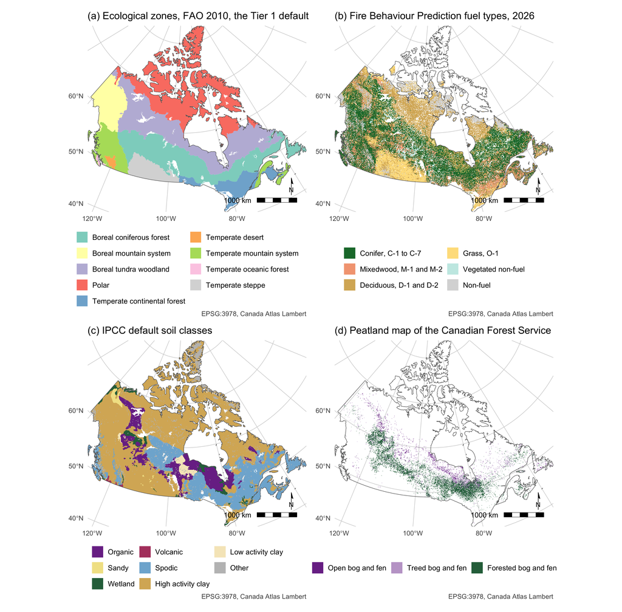

Fig. 1 The global default layers of the Tier 1 fire estimate beside the national datasets of the higher tiers, four maps on one scale in EPSG:3978. (a) The ecological zones of FAO 2010, the default stratification of the IPCC biomass consumption table (Aalde et al., 2006, pp. 2.45–2.46). (b) The fuel types of the Fire Behaviour Prediction System, 2026 release, grouped by fuel. (c) The IPCC default soil classes. (d) The peatland map of the Canadian Forest Service, bog and fen by canopy. Map lines delineate study areas and do not necessarily depict accepted national boundaries.

```r
map_theme <- ggplot2::theme_minimal(base_size = 7) + ggplot2::theme(
  panel.grid = ggplot2::element_line(colour = "grey80", linewidth = 0.15), axis.text = ggplot2::element_text(size = 5, colour = "grey30"),
  legend.position = "bottom", legend.key.size = ggplot2::unit(0.3, "cm"), legend.text = ggplot2::element_text(size = 5.5),
  legend.title = ggplot2::element_blank(), legend.margin = ggplot2::margin(0, 0, 0, 0), legend.location = "plot",
  plot.title = ggplot2::element_text(size = 7.5, hjust = 0), plot.caption = ggplot2::element_text(size = 5, colour = "grey30"),
  plot.background = ggplot2::element_rect(fill = "white", colour = NA))
bb <- sf::st_bbox(gez)
canada_coord <- ggplot2::coord_sf(crs = 3978, expand = FALSE, xlim = bb[c("xmin", "xmax")], ylim = bb[c("ymin", "ymax")])
furniture <- function() list(
  ggspatial::annotation_scale(location = "br", width_hint = 0.22, height = ggplot2::unit(0.12, "cm"), text_cex = 0.45, line_width = 0.3),
  ggspatial::annotation_north_arrow(location = "br", pad_y = ggplot2::unit(0.45, "cm"), height = ggplot2::unit(0.45, "cm"), width = ggplot2::unit(0.3, "cm"),
                                    style = ggspatial::north_arrow_minimal(text_size = 5, line_width = 0.5)),
  ggplot2::labs(caption = "EPSG:3978, Canada Atlas Lambert"))
outline_layer <- ggplot2::geom_sf(data = canada_outline, fill = NA, colour = "grey40", linewidth = 0.15)
soil_cols <- c(Organic = "#7B3294", Sandy = "#F2E394", Wetland = "#2C6E49", Volcanic = "#B2456E", Spodic = "#7FB3D5",
               `High activity clay` = "#D8B365", `Low activity clay` = "#F6E8C3", Other = "#BFBFBF")
fbp_cols <- setNames(c("#1B7837", "#F4A582", "#D8B365", "#FEE08B", "#C7EAE5", "#D9D9D9"), fbp_labels)
cfs_peat_cols <- setNames(c("#7B3294", "#C2A5CF", "#2C6E49"), peat_labels)
p_a <- ggplot2::ggplot() + ggplot2::geom_sf(data = gez, ggplot2::aes(fill = gez_name), colour = NA) + outline_layer +
  ggplot2::scale_fill_brewer(palette = "Set3") + ggplot2::guides(fill = ggplot2::guide_legend(ncol = 2)) + canada_coord + furniture() +
  ggplot2::labs(title = "(a) Ecological zones, FAO 2010, the Tier 1 default") + map_theme
p_b <- ggplot2::ggplot() + tidyterra::geom_spatraster(data = fbp_r, maxcell = 3e5) + outline_layer +
  ggplot2::scale_fill_manual(values = fbp_cols, na.value = NA, na.translate = FALSE) + ggplot2::guides(fill = ggplot2::guide_legend(ncol = 2)) +
  canada_coord + furniture() + ggplot2::labs(title = "(b) Fire Behaviour Prediction fuel types, 2026") + map_theme
p_c <- ggplot2::ggplot() + tidyterra::geom_spatraster(data = soil_r, maxcell = 3e5) + outline_layer +
  ggplot2::scale_fill_manual(values = soil_cols, na.value = NA, na.translate = FALSE) + ggplot2::guides(fill = ggplot2::guide_legend(ncol = 3)) +
  canada_coord + furniture() + ggplot2::labs(title = "(c) IPCC default soil classes") + map_theme
p_d <- ggplot2::ggplot() + tidyterra::geom_spatraster(data = cfs_peat_r, maxcell = 3e5) + outline_layer +
  ggplot2::scale_fill_manual(values = cfs_peat_cols, na.value = NA, na.translate = FALSE) + ggplot2::guides(fill = ggplot2::guide_legend(ncol = 3)) +
  canada_coord + furniture() + ggplot2::labs(title = "(d) Peatland map of the Canadian Forest Service") + map_theme
patchwork::wrap_plots(p_a, p_b, p_c, p_d, ncol = 2)
```

Each fire was placed by its reported location in a zone, soil class, land cover class and, inside British Columbia, the province. Each fire’s biomass consumption was the IPCC row of its zone and fire type (Table 1). Boreal crown and surface fires took their own rows and other boreal fires the general wildfire row. Temperate fires took the wildfire row of other temperate forests and polar fires the tundra row. Grassland fires of April to June took the early dry season row and later fires the mid or late season row. The IPCC biomass consumption table gave peat a fuel of 41 ± 1.4 tonnes per hectare, but the emission factor table had no peat row (Aalde et al., 2006, pp. 2.45–2.47). The 2013 Wetlands Supplement gave peat fuel loads and emission factors for undrained and drained organic soils, in Equation 2.8 and two default tables (Hiraishi et al., 2014, pp. 2.37–2.41). A fire on organic soil therefore had a second term, the undrained peat row of 66 tonnes per hectare with the boreal and temperate emission factors.

**EQUATION 2.8** Annual CO<sub>2</sub>-C and non-CO<sub>2</sub> emissions from organic soil fire

$$L_{\text{fire}} = A \cdot M_{B} \cdot C_{f} \cdot G_{ef} \cdot 10^{-3}$$

Where  
$L_{\text{fire}}$ = amount of CO<sub>2</sub> or non-CO<sub>2</sub> emissions, e.g. CH<sub>4</sub> from fire, tonnes  
$A$ = total area burnt annually, ha  
$M_{B}$ = mass of fuel available for combustion, tonnes ha<sup>-1</sup> (i.e. mass of dry organic soil fuel)  
$C_{f}$ = combustion factor, dimensionless  
$G_{ef}$ = emission factor for each gas, g kg<sup>-1</sup> dry matter burnt

Reproduced from Chapter 2 of the 2013 Wetlands Supplement, page 2.37, with the references to its tables omitted (Hiraishi et al., 2014).

```r
readr::write_csv(rows_table, "03.outputs/TBL/tbl-rows.csv")
fmt_tbl(rows_table, right = c("Biomass consumption (t/ha)", "Combustion factor"))
```

Table 1 Rows of the 2006 IPCC Guidelines for Canada’s vegetation, with biomass consumption as mean and standard error and the combustion factor as mean and standard deviation (Aalde et al., 2006, pp. 2.45–2.49). The emission factor row is the row of the IPCC emission factor table each vegetation type took (Aalde et al., 2006, p. 2.47). The organic soil rows are those of the 2013 Wetlands Supplement, as mean and 95 per cent interval (Hiraishi et al., 2014, pp. 2.40–2.41). The Supplement gave emission factors of 362 ± 41 g of carbon dioxide carbon and 9 ± 4 g of methane per kilogram. A blank is a value the table did not print.

| Vegetation | Subcategory | Biomass consumption (t/ha) | Combustion factor | Emission factor row |
| --- | --- | --- | --- | --- |
| Boreal forest | Wildfire (general) | 52.8 ± 48.4 | 0.40 ± 0.06 | Extra tropical forest |
| Boreal forest | Crown fire | 25.1 ± 7.9 | 0.43 ± 0.21 | Extra tropical forest |
| Boreal forest | Surface fire | 21.6 ± 25.1 | 0.15 ± 0.08 | Extra tropical forest |
| Boreal forest | Post logging slash burn | 69.6 ± 44.8 | 0.33 ± 0.13 | Extra tropical forest |
| Boreal forest | Land clearing fire | 87.5 ± 35.0 | 0.59 | Extra tropical forest |
| Boreal forest | All boreal forest | 41.0 ± 36.5 | 0.34 ± 0.17 | Extra tropical forest |
| Other temperate forests | Wildfire | 19.8 ± 6.3 |  | Extra tropical forest |
| Other temperate forests | Post logging slash burn | 77.5 ± 65.0 | 0.62 ± 0.12 | Extra tropical forest |
| Other temperate forests | Felled and burned (land clearing fire) | 48.4 ± 62.7 | 0.51 | Extra tropical forest |
| Other temperate forests | All other temperate forests | 50.4 ± 53.7 | 0.45 ± 0.16 | Extra tropical forest |
| Shrublands | Shrubland (general) | 26.7 ± 4.2 | 0.95 | Savanna and grassland |
| Shrublands | All shrublands | 14.3 ± 9.0 | 0.72 ± 0.25 | Savanna and grassland |
| Savanna grasslands and pastures | All savanna grasslands (early dry season burns) | 2.1 | 0.74 | Savanna and grassland |
| Savanna grasslands and pastures | Grassland (mid or late dry season burns) | 4.1 ± 3.1 | 0.77 ± 0.26 | Savanna and grassland |
| Other vegetation types | Peatland | 41.0 ± 1.4 |  |  |
| Other vegetation types | Tundra | 10.0 |  | Savanna and grassland |
| Organic soil, boreal and temperate | Wildfire (undrained peat) | 66 (46 to 86) | 1 | Wetlands Supplement, boreal and temperate |
| Organic soil, boreal and temperate | Wildfire (drained peat) | 336 ± 4 | 1 | Wetlands Supplement, boreal and temperate |

The Tier 1 estimate was rebuilt by zone from the fires of 2001 to 2024, summed by zone and year, with the zone’s biomass consumption and emission factors. Methane and nitrous oxide were converted at the inventory’s warming potentials of 28 and 265 (ECCC, 2026). Zones sharing a row shared its error, so their emissions were summed before the rows were combined in quadrature. The estimate was rebuilt again by stratum for Canada and British Columbia, with each fire’s row and the peat term. The area burned was summed by year and cause. The zone rows were also applied to each MCD64A1 pixel of the algorithm’s burned area. The 2023 estimate thus changed one input at a time, from the algorithm’s method to the strata with the peat term. On a 2 km grid, each cell took the row of its zone and land cover, and the organic soil row where the soil raster was organic. On the grid, forest included woody savanna and savanna, classes 8 and 9, whose tree cover exceeded 10 per cent. Three national layers of a higher tier were set beside the defaults term by term (Fig. 1). The fuel types of the Fire Behaviour Prediction System, 2026 release, were grouped into conifer, mixedwood, deciduous, grass and non-fuel from the labels of the catalogue’s map service (Canadian Forest Service, 2026b). The peatland map of the Canadian Forest Service gave bog and fen by canopy at 250 m (Webster et al., 2018). The National Burned Area Composite, the inventory’s source of burned area, gave the national total for each year (Canadian Forest Service, 2026c; ECCC, 2026). Each layer was projected to the 2 km grid, where the organic soil of the IPCC raster was compared cell by cell with the peatland map. The 2023 fires were placed on the peatland map and the fuel types. Canada’s higher tier fuel data also included forest floor loads and consumption (de Groot et al., 2009), dead and down woody debris loads (Hanes et al., 2021) and crown fuel consumption (de Groot et al., 2022).

## 2.2 Disaggregation and baselines

The disaggregation followed the 2019 Refinement, which called it “good practice that subsequent removals are also disaggregated until the balance has been reached” (Ogle et al., 2019, p. 2.72). The land use sector table of Canada’s 2026 national inventory report to the United Nations Framework Convention on Climate Change gave seven categories and their total (ECCC, 2026, p. 195). Beneath the total, the table gave one more line, natural disturbances, marked “Not a reporting category” and “provided solely for transparency purposes” (ECCC, 2026, p. 195). The line was the net balance of emissions and removals from natural disturbances in the managed forest, which the total left out. Every wildfire in the managed forest went to the line, whatever its cause. Disturbances that killed a fifth or less of a mature stand’s biomass, slash burning and prescribed burning stayed in the total (ECCC, 2026). The forest values came from CBM-CFS3, which grew each stand along a yield curve and moved its carbon through a disturbance matrix (Kurz et al., 2018). The total and the line were read for Canada and British Columbia for every year from 1990 to 2024 (Fig. 2).

```r
# Table 6-1, Net Greenhouse Gas Flux Estimates in the Land Use, Land-Use Change and Forestry Sector,
# All Inventory Years, by province and territory, Environment and Climate Change Canada,
# National Inventory Report 1990-2024
# https://data-donnees.az.ec.gc.ca/data/substances/monitor/canada-s-official-greenhouse-gas-inventory/E-LULUCF/?lang=en
if (!file.exists("02.inputs/eccc/lulucf-2026-categories.csv")) {
  if (!file.exists("02.inputs/eccc/raw/table-6-1.xlsx")) {
    dir.create("02.inputs/eccc/raw", showWarnings = FALSE, recursive = TRUE)
    download.file(paste0("https://data-donnees.az.ec.gc.ca/api/file?path=", URLencode("/substances/monitor/canada-s-official-greenhouse-gas-inventory/E-LULUCF/NIR2026_Table 6-1_All_Years_PTs.xlsx", reserved = TRUE)), "02.inputs/eccc/raw/table-6-1.xlsx", mode = "wb")
  }
  sheets <- readxl::excel_sheets("02.inputs/eccc/raw/table-6-1.xlsx")
  readxl::read_excel("02.inputs/eccc/raw/table-6-1.xlsx", sheet = grep("NATIONAL$", sheets, value = TRUE), skip = 3, col_types = "text", .name_repair = "unique_quiet") |>
    dplyr::transmute(category = dplyr::case_when(grepl("TOTAL", ...1) ~ "Sector total", grepl("^Natural disturbances", ...2) ~ "Natural disturbances", grepl("^[a-g]\\.$", ...1) ~ ...2),
                     dplyr::across(dplyr::matches("^[0-9]{4}$"), as.numeric)) |>
    dplyr::filter(!is.na(category)) |>
    tidyr::pivot_longer(-category, names_to = "year", values_to = "kt", names_transform = as.integer) |>
    readr::write_csv("02.inputs/eccc/lulucf-2026-categories.csv", na = "")
}

categories <- readr::read_csv("02.inputs/eccc/lulucf-2026-categories.csv", show_col_types = FALSE) |>
  dplyr::filter(!is.na(kt)) |>
  dplyr::mutate(mt = kt / 1000,
                panel = factor(dplyr::if_else(category == "Natural disturbances", "Natural disturbances, shown beside the total and left out of it", "Reported categories and their total"), levels = c("Reported categories and their total", "Natural disturbances, shown beside the total and left out of it")),
                category = factor(category, levels = c("Forest Land", "Cropland", "Grassland", "Wetlands", "Settlements", "Harvested Wood Products", "Sector total", "Natural disturbances")))

ggplot2::ggplot(categories, ggplot2::aes(year, mt, colour = category)) +
  ggplot2::geom_hline(yintercept = 0, linewidth = 0.3, colour = "grey60") +
  ggplot2::geom_line() +
  ggplot2::facet_wrap(~panel, ncol = 1, scales = "free_y") +
  ggplot2::scale_colour_manual(values = unname(grDevices::palette.colors(8, "Okabe-Ito"))) +
  ggplot2::labs(x = NULL, y = expression("Net emissions (Mt CO"[2]*"e)"), colour = NULL) +
  th +
  ggplot2::theme(legend.position = "bottom")
```

[output not shown]

Four treatments of the natural disturbance line were compared. No disaggregation added the line to the reported total in every year and Canada’s approach in none, giving the undisaggregated and disaggregated accounts, respectively (ECCC, 2026). The threshold rule took the form of Australia’s test, classing a year as natural when a test series exceeded its baseline mean by two standard deviations (Bowman et al., 2023). The rule left the whole line out of a natural year, including the regrowth of earlier disturbances, because Canada published the line as one value a year. Australia’s inventory instead tracked the land of an excluded fire “until the time forest carbon has returned to its original state” (Bowman et al., 2023, p. 4). The threshold account applied the rule on a 13 year baseline to the forest fire series, Canada’s forest fire carbon dioxide in the estimates generated by the FAOSTAT algorithm (FAO, 2025). That series was the kind of national fire emissions Australia’s test used (Bowman et al., 2023). For British Columbia, a natural season also had to pass the rule’s second step, on burned area from the Canadian National Fire Database for the same 13 years (Bowman et al., 2023, p. 4; Canadian Forest Service, 2026a).

The background level method of the 2013 Kyoto Protocol Supplement removed every year above the baseline mean plus twice the standard deviation of Equation 2.3.1, recomputing both until none remained (IPCC, 2014, p. 2.49). The final mean was the background level and twice the final standard deviation the margin (IPCC, 2014, p. 2.49). A year above the background level plus the margin counted only the background level, and every other year counted the line as reported (IPCC, 2014, p. 2.50). On burned area, such a year kept the share of its line equal to the background area over the year’s burned area. The Supplement built its background level from the annual emissions of natural disturbances, whereas on the line it was set on a net balance including the removals of regrowth (IPCC, 2014, p. 2.46).

**EQUATION 2.3.1** Calculation of the standard deviation for the annual emissions for the calibration period

$$SD = \sqrt{\sum_{i=1}^{N}\left(x_{i} - \bar{X}\right)^{2} \Big/ \left(N - 1\right)}$$

Where  
$x_{i}$ = the emission estimate for year $i$, $i$ = 1, 2…, $N$ where $N$ is the number of years in the calibration period for which emission estimates are available.  
$\bar{X}$ = the arithmetic mean of all $x_{i}$, i.e. $\bar{X} = \sum_{i=1}^{N} x_{i} / N$.

Reproduced from Chapter 2 of the 2013 Revised Supplementary Methods and Good Practice Guidance Arising from the Kyoto Protocol, page 2.49 (IPCC, 2014).

The test series were the forest fire series from 2001, the line from 1990 and the National Burned Area Composite from 1972 (Canadian Forest Service, 2026c; ECCC, 2026; FAO, 2025), documented only back to 1986 (Skakun et al., 2022). The threshold rule and the background level were the two test-based treatments, each deciding by a statistical test on a baseline which years to change. The baselines ended in 2016, the last reference year, and ran from 13 years, the length of Australia’s 2000 to 2012 baseline, to the longest each record allowed (Bowman et al., 2023, p. 4). The threshold rule ran at 13 and 16 years on the forest fire series. The threshold rule and the background level ran at 13, 20 and 27 years on the line, and at 13, 20, 27, 35 and 45 years on burned area. The 30 years at which twice the standard deviation approximated Student’s t served only as a rule of thumb (Ogle et al., 2019, p. 2.77). Annual fire emissions were skewed and trending, so mean plus two standard deviations had no fixed chance of being exceeded at any record length. The composite and the forest fire series covered all of Canada, so a year could pass a test on fire outside the managed forest that the line covered. For every treatment and baseline, each account was compared with its own 2012 to 2016 mean, five years as in the reference period of ART TREES (ART, 2026b, p. 33). The reduction in each year of 2017 to 2024 was that mean minus the year’s net emissions, as in Equation 10 of ART TREES (ART, 2026b, p. 61). The undisaggregated and disaggregated accounts were also compared over 1990 to 2024 by the mean and standard deviation of their annual net emissions, extending the averages Kurz et al. (2018) reported.

In fire histories simulated with management fixed, burned area followed the composite’s log-linear trend for 1972 to 2024, with residuals resampled with replacement (Canadian Forest Service, 2026c). The line followed its regression on burned area and year for 1990 to 2024, also with resampled residuals. The rest of the land use sector was held at its 2012 to 2016 mean, so every reduction came from natural disturbance and the treatment. Canada’s approach therefore gave zero and served as the reference. The simulated line had no lagged regrowth, since each year’s value followed only that year’s burned area and the year. The residuals were resampled independently by year, so the histories had no runs of high fire years, and the fitted trends and slopes were used without their uncertainty. In 2,000 histories, the threshold rule ran on burned area alone, since the histories had no forest fire series, and each test kept its baselines from the record. Each treatment was judged by two measures from the 2013 Kyoto Protocol Supplement (IPCC, 2014, pp. 2.31, 2.50). The mean annual reduction from natural disturbance alone was zero where a treatment avoided “the expectation of net credits or net debits” (IPCC, 2014, p. 2.50). The half width of the 90 per cent range of annual reductions was the smallest change in management one year could show against natural disturbance. Two checks removed the trends in turn, the first holding the line’s year term at 2014, the middle of the reference period. The second also held burned area at the mean of its fitted log values. Each mean was given with the standard deviation of the annual reductions over all histories and years. The eight years of one history shared its reference mean, so the 95 per cent confidence interval of each mean came from the 2,000 history means. The mean annual reduction was compared across the five runs on a 13 year baseline by repeated-measures analysis of variance, with the history as the subject. The same test compared the baselines within each treatment that ran on more than one. The histories were drawn in R 4.4.1 with the seed 2026.

To show how a percentage deduction behaved, the uncertainty deduction of ART TREES, Equations 8 and 27 below, was applied to each reduction. The standard’s buffer withheld 5 to 25 per cent of the reductions, as set by its risk rating tool (ART, 2026b, pp. 55–56; 2026a, p. 3). After a reversal, a year above the five-year mean that followed a year below it, the buffer was 30 per cent for five calendar years (ART, 2026b, pp. 55–56).

**EQUATION 8** Emission Reduction Uncertainty Adjustment Factor

$$UA_{ER,t} = 0.524417 \times \frac{90\%\ CI_{ER,t}}{1.645006}$$

**EQUATION 27** Emission Reduction Uncertainty Deduction

$$UNC_{ER,t} = GHG\ ER_{t} \times UA_{ER,t}$$

Where  
$UA_{ER,t}$ = TREES emission reduction uncertainty adjustment factor in calendar year t  
0.524417 = t value at ART allowable risk  
$90\%\ CI_{ER,t}$ = Half width of 90% confidence interval for emission reductions expressed as a percent of the mean emission reductions in calendar year t; %  
1.645006 = t value at 90% confidence level  
$UNC_{ER,t}$ = TREES emission reduction uncertainty deduction in calendar year t; tCO2e  
$GHG\ ER_{t}$ = GHG ERs in calendar year t; tCO2e

Reproduced from ART TREES version 3.0, pages 58, 59 and 69 (ART, 2026b).

The uncertainty of each account followed Approach 2 of the Refinement’s uncertainty chapter, Monte Carlo simulation, which ART TREES also required with 10,000 runs (ART, 2026b, p. 58; Paciornik et al., 2019). The published uncertainty of CBM-CFS3 was a 95 per cent interval 16.6 Tg C a year above its median and 15.6 below (Metsaranta et al., 2017). Each run drew the five reference years and each year of 2017 to 2024 from normal distributions whose standard deviation, for every account, was the larger side over 1.96. This single standard deviation assumed the model was as certain of a year of extreme fire as of a year with little fire. The half width in Equation 8 was half the distance between the 5th and 95th percentiles of the draws. The draws treated the error of each year as independent, whereas ART TREES excluded model error as “consistent between emissions in the reference period and crediting period” (ART, 2026b, p. 58). The share of error variance common to all years, the common share, was therefore varied. Under the normal model, the common share left the mean unchanged and scaled the half width by the square root of one minus that share. The common share at which every positive year kept part of its reduction was solved from the same relation. ART TREES also allowed an uncertainty “across the crediting period based on the summed gross emission reductions or removals” (ART, 2026b, p. 58). The period uncertainty came from the same draws, for the disaggregated and threshold accounts.

# 3 Results

## 3.1 Fire estimates

```r
readr::write_csv(zones_table, "03.outputs/TBL/tbl-zones.csv")
fmt_tbl(zones_table, right = names(zones_table)[-1])
```

Table 2 The Tier 1 fire estimate for Canada by ecological zone from the national fire record, 2023, with each zone’s burned area averaged over 2001 to 2024. Biomass consumption and the emission factors were the zone’s rows of the Tier 1 defaults in Online Resource 1. The uncertainty was the Approach 1 half width of the 95 per cent interval for carbon dioxide, with no error on burned area. The last row was the estimate generated by the FAOSTAT algorithm.

| Ecological zone | Burned 2001 to 2024 (kha a year) | Burned 2023 (kha) | Biomass consumption (t/ha) | CO2 (Mt) | CH4 (kt) | N2O (kt) | CO2e (Mt) | Uncertainty (%) |
| --- | --- | --- | --- | --- | --- | --- | --- | --- |
| Boreal tundra woodland | 1355 | 10967 | 52.8 | 908.6 | 2722 | 150.6 | 1024.7 | 180 |
| Boreal coniferous forest | 1226 | 4912 | 52.8 | 407.0 | 1219 | 67.4 | 459.0 | 180 |
| Temperate mountain system | 199 | 744 | 19.8 | 23.1 | 69 | 3.8 | 26.0 | 64 |
| Boreal mountain system | 249 | 634 | 52.8 | 52.5 | 157 | 8.7 | 59.2 | 180 |
| Temperate desert | 46 | 179 | 4.1 | 1.2 | 2 | 0.2 | 1.3 | 149 |
| Temperate continental forest | 25 | 81 | 19.8 | 2.5 | 8 | 0.4 | 2.8 | 64 |
| Polar | 6 | 68 | 10.0 | 1.1 | 2 | 0.1 | 1.2 |  |
| Temperate steppe | 5 | 15 | 4.1 | 0.1 | 0 | 0.0 | 0.1 | 149 |
| Temperate oceanic forest | 0 | 4 | 19.8 | 0.1 | 0 | 0.0 | 0.1 | 64 |
| All zones | 3112 | 17604 | 50.5 | 1396.2 | 4179 | 231.3 | 1574.5 | 177 |
| FAOSTAT, other forest, one coefficient | 340 | 2750 | 42.2 | 187.0 | 267 | 24.3 | 200.9 | 175 |

In 2023, the national fire record placed 17.6 Mha of fire in Canada’s ecological zones, 94 per cent in the three boreal zones (Table 2). Boreal tundra woodland alone burned 11.0 Mha. Equation 2.27 gave 1,396 Mt of carbon dioxide (Aalde et al., 2006, pp. 2.42–2.47). The boreal zones took the boreal wildfire row of 52.8 tonnes per hectare and the extra tropical forest emission factors. The row’s standard error of 48.4 gave the national total an uncertainty of 177 per cent. The total’s 95 per cent interval therefore contained zero.

```r
ggplot2::ggplot(cause_year, ggplot2::aes(year, mha, fill = cause)) +
  ggplot2::geom_col(width = 0.8) +
  ggplot2::facet_wrap(~region, ncol = 1, scales = "free_y") +
  ggplot2::scale_fill_manual(values = c(Natural = "#D7301F", Human = "#0570B0", Unknown = "grey60"), name = NULL) +
  ggplot2::scale_x_continuous(breaks = seq(2001, 2024, 2)) +
  ggplot2::labs(x = NULL, y = "Area burned (Mha)") +
  th + ggplot2::theme(legend.position = "bottom")
```

[output not shown]

```r
readr::write_csv(strata_table, "03.outputs/TBL/tbl-strata.csv")
fmt_tbl(strata_table, right = names(strata_table)[-(1:2)])
```

Table 3 The Tier 1 fire estimate for 2023 by stratum, for Canada and for British Columbia (BC), from the fire points. Each fire took the row of Table 1 for its ecological zone and fire type. Every fire on organic soil also took the undrained peat row of the Wetlands Supplement as a second term. Ignition, fire type and month are the record’s own fields; the soil class and the land cover are the raster values at the fire’s location.

| Stratum | Class | Canada burned (kha) | Canada vegetation CO2e (Mt) | Canada organic soil CO2e (Mt) | BC burned (kha) | BC vegetation CO2e (Mt) | BC organic soil CO2e (Mt) |
| --- | --- | --- | --- | --- | --- | --- | --- |
| Ignition | Natural | 16220 | 1372.2 | 457.4 | 2758 | 203.0 | 103.6 |
|  | Unknown | 888 | 56.5 | 32.2 | 93 | 6.5 | 0.2 |
|  | Human | 496 | 39.9 | 0.5 | 49 | 3.8 | 0.0 |
| Fire type | Unspecified | 15523 | 1380.0 | 403.4 | 2899 | 213.2 | 103.8 |
|  | Surface | 1028 | 39.3 | 52.7 | 0 | 0.0 | 0.0 |
|  | Crown | 1000 | 44.4 | 33.0 | 0 | 0.0 | 0.0 |
|  | Ground | 53 | 5.0 | 1.1 | 0 | 0.0 | 0.0 |
|  | Prescribed | 0 | 0.0 | 0.0 | 0 | 0.0 | 0.0 |
| Month | April to May | 6545 | 529.9 | 195.4 | 1040 | 96.6 | 30.2 |
|  | July | 5016 | 414.7 | 166.4 | 1086 | 61.7 | 35.9 |
|  | June | 4793 | 412.6 | 67.5 | 631 | 45.5 | 30.2 |
|  | August to October | 1248 | 111.2 | 60.8 | 142 | 9.3 | 7.5 |
|  | Other months | 2 | 0.2 | 0.1 | 0 | 0.0 | 0.0 |
| Soil class | Mineral | 12496 | 1035.3 | 0.0 | 1895 | 119.6 | 0.0 |
|  | Organic | 4702 | 395.9 | 490.1 | 996 | 93.0 | 103.8 |
|  | Other | 406 | 37.5 | 0.0 | 9 | 0.6 | 0.0 |
| Land cover | Woody savanna, IGBP 8 | 8605 | 688.0 | 330.3 | 1367 | 99.0 | 77.8 |
|  | Savanna, IGBP 9 | 5241 | 487.6 | 117.3 | 1 | 0.1 | 0.0 |
|  | Forest, IGBP 1 to 5 | 2704 | 205.4 | 42.2 | 1458 | 112.9 | 26.0 |
|  | Shrubland, IGBP 6 to 7 | 506 | 43.5 | 0.1 | 0 | 0.0 | 0.0 |
|  | Other | 334 | 29.6 | 0.0 | 8 | 0.5 | 0.0 |
|  | Wetland, IGBP 11 | 140 | 13.1 | 0.2 | 0 | 0.0 | 0.0 |
|  | Grassland, IGBP 10 | 73 | 1.5 | 0.0 | 65 | 0.8 | 0.0 |
| All fires |  | 17604 | 1468.6 | 490.1 | 2899 | 213.2 | 103.8 |

Of the area burned in 2023, 92 per cent was recorded as natural in cause and 3 per cent as human (Table 3). Between 2001 and 2024, the natural share was 88 per cent and no year fell below 36 per cent, as the yearly areas by cause in Online Resource 2 showed. Fire agencies recorded a crown, surface or ground fire type for 12 per cent of the 2023 area, and the rest took the general wildfire row. Fires on organic soil covered 27 per cent of the area burned in Canada and 34 per cent in British Columbia. The peat term added 490 Mt of carbon dioxide equivalent to the vegetation term’s 1,469 Mt in Canada, and 104 Mt to 213 Mt in the province. On the MCD12Q1 map, 15 per cent of the 2023 area was forest and 79 per cent woody savanna and savanna. On the 2 km grid, 380 Mha of Canada took the boreal forest row and 109 Mha the temperate row, with 76 Mha of boreal forest on organic soil.

```r
readr::write_csv(tier2_table, "03.outputs/TBL/tbl-tier2.csv")
fmt_tbl(tier2_table)
```

Online Resource 3 set each Tier 1 default beside its national dataset. The national layers split land that the defaults treated as one class. Where the IPCC biomass consumption table gave Canada’s forest two rows (Aalde et al., 2006, p. 2.45), the 2026 fuel type map gave conifer 300 Mha, mixedwood 88 Mha and deciduous 198 Mha (Canadian Forest Service, 2026b). The 2023 fires burned 39 per cent of their area in conifer, 24 per cent in mixedwood and 27 per cent in deciduous fuel (Fig. 1). The national peatland map showed 96 Mha of bog and fen, against 92 Mha of organic soil in the IPCC raster, and only 32 Mha was organic in both (Batjes, 2010; Webster et al., 2018). The 2023 fires therefore fell 21 per cent on the peatland map against 27 per cent on the default raster. In 2023, the National Burned Area Composite recorded 14.8 Mha and the national fire record 17.6 Mha (Canadian Forest Service, 2026c). The estimates generated by the FAOSTAT algorithm counted 13.1 Mha of MCD64A1 burned area. Canada’s inventory took every term from national data rather than from the IPCC defaults (ECCC, 2026).

For 2023, the estimates generated by the FAOSTAT algorithm gave Canada’s forest fires 187 Mt of carbon dioxide, 12.4 times their mean of 2001 to 2022 (FAO, 2025). The total came from 2,749,985 hectares in the other forest item, at 42.2 tonnes of dry matter per hectare. The rerun matched the algorithm’s burned area within 1 per cent in every year over the five items. Of the 123 item and year values, 100 per cent fell within 2 per cent of the estimates. The algorithm classed 2023 with the 2022 land cover map and 2024 with the 2023 map, the latest it had. The algorithm’s forest pixels covered 2.40 Mha in boreal and 0.34 Mha in temperate zones. At the IPCC rows for all boreal and all other temperate forests, the pixels gave 42.2 tonnes per hectare, the fuel in the estimates (Aalde et al., 2006, p. 2.45). The recovered coefficients, 1,613 g of carbon dioxide and 2.3 g of methane per kilogram, were those of the savanna and grassland row of the IPCC emission factor table (Aalde et al., 2006, p. 2.47). Online Resource 4 listed the recovered coefficients of each item. The methane coefficient was 49 per cent of the extra tropical forest value.

The algorithm placed 86 per cent of the area burned between 2001 and 2024 in its savanna, grassland and shrubland items (FAO, 2025). The items took 3.3 and 4.1 tonnes of dry matter per hectare, and “only the non-CO<sub>2</sub> emissions (N<sub>2</sub>O and CH<sub>4</sub>) are disseminated” for them, following the IPCC Guidelines (FAO, 2025). The woody savanna and savanna classes of the MCD12Q1 map took savanna fuel values in the estimates. Canada’s organic soil fires were zero in the estimates, as for every country outside Southeast Asia (FAO, 2025). In the 20 years both sources reported, the forest fire estimate was a median of 2.6 times the value Canada submitted. By Equations 3.1 and 3.2, the fuel term gave 174 to 209 per cent and the emission factor 12 per cent. The two terms gave 175 to 209 per cent, so the 2023 estimate lay within −140 to 514 Mt, an interval containing zero. The zone estimate of carbon dioxide from the national fire record was 7.5 times the algorithm’s, with 4,179 kt of methane against 267 kt.

```r
readr::write_csv(coefficients, "03.outputs/TBL/tbl-coefficients.csv")
fmt_tbl(coefficients, right = c("Burned area (ha a year)", "Fuel (t/ha)", "CH4 (g/kg)", "N2O (g/kg)", "CO2 (g/kg)"))
```

## 3.2 Accounts and reductions

Between 1990 and 2024, disaggregating natural disturbance cut the standard deviation of Canada’s annual net emissions from 190 to 24 Mt CO<sub>2</sub>e, a factor of 7.9 (Fig. 2). The account Canada reported averaged 44.6 ± 24.0 Mt CO<sub>2</sub>e a year (95 per cent confidence interval 36.3 to 52.8). The undisaggregated account averaged 119.9 ± 190.0 Mt CO<sub>2</sub>e a year (95 per cent confidence interval 54.7 to 185.2). British Columbia’s reported account averaged 27.2 ± 14.9 Mt CO<sub>2</sub>e a year (95 per cent confidence interval 22.0 to 32.3). The province’s undisaggregated account averaged 60.8 ± 99.4 Mt CO<sub>2</sub>e a year (95 per cent confidence interval 26.6 to 94.9), a standard deviation 6.7 times larger. In 2023, Canada reported −8.7 Mt and British Columbia 19 Mt, where the undisaggregated accounts showed 991 and 399 Mt.

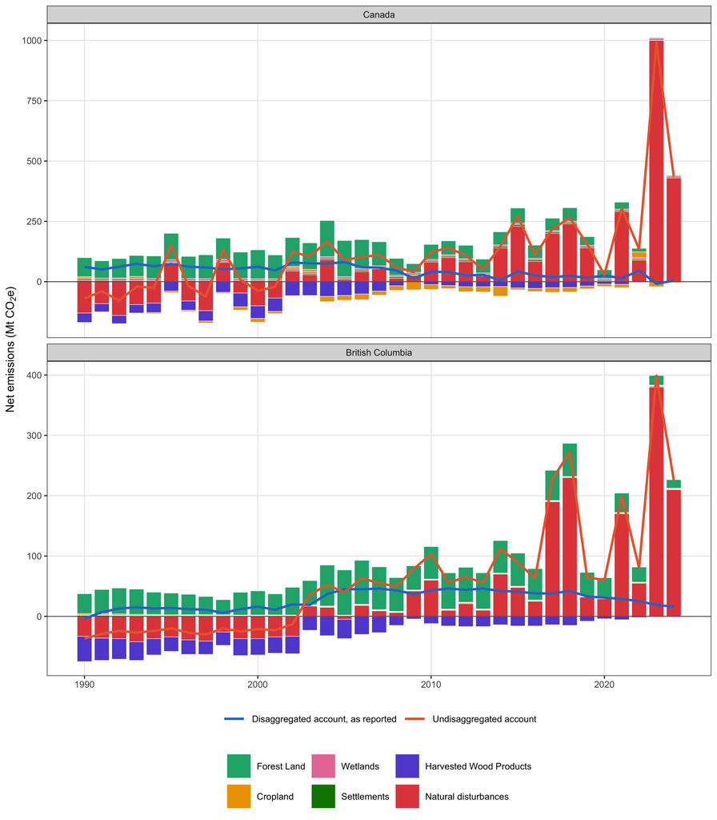

Fig. 2 Net emissions of the land use sector for Canada and British Columbia, 1990 to 2024, by inventory category, with the natural disturbance line that the reported total left out. The lines give the disaggregated account, the total Canada reported, and the undisaggregated account, that total plus the natural disturbance line. In Canada, Wetlands, at 5.4 to 10.0 Mt CO2e a year, and Settlements, at 3.7 to 6.3 Mt, were too small to show at this scale.

```r
# Table 6-1, Net Greenhouse Gas Flux Estimates in the Land Use, Land-Use Change and Forestry Sector,
# All Inventory Years, by province and territory, Environment and Climate Change Canada,
# National Inventory Report 1990-2024, the sheet for British Columbia
# https://data-donnees.az.ec.gc.ca/data/substances/monitor/canada-s-official-greenhouse-gas-inventory/E-LULUCF/?lang=en
if (!file.exists("02.inputs/eccc/lulucf-2026-categories-bc.csv")) {
  readxl::read_excel("02.inputs/eccc/raw/table-6-1.xlsx", sheet = "Table 6-1 BC", skip = 3, col_types = "text", .name_repair = "unique_quiet") |>
    dplyr::transmute(category = dplyr::case_when(grepl("TOTAL", ...1) ~ "Sector total", grepl("^Natural disturbances", ...2) ~ "Natural disturbances", grepl("^[a-g]\\.$", ...1) ~ ...2),
                     dplyr::across(dplyr::matches("^[0-9]{4}$"), as.numeric)) |>
    dplyr::filter(!is.na(category)) |>
    tidyr::pivot_longer(-category, names_to = "year", values_to = "kt", names_transform = as.integer) |>
    readr::write_csv("02.inputs/eccc/lulucf-2026-categories-bc.csv", na = "")
}

# Categories as stacked bars, with the natural disturbance line as one more bar, and the two accounts as lines.
# The eight colours are the validated categorical order, accounts first, and Grassland is left out at zero throughout
regions <- c("Canada", "British Columbia")
cats <- c("Forest Land", "Cropland", "Wetlands", "Settlements", "Harvested Wood Products", "Natural disturbances")
bars <- dplyr::bind_rows(Canada = readr::read_csv("02.inputs/eccc/lulucf-2026-categories.csv", show_col_types = FALSE),
                         `British Columbia` = readr::read_csv("02.inputs/eccc/lulucf-2026-categories-bc.csv", show_col_types = FALSE), .id = "region") |>
  dplyr::filter(!is.na(kt), category %in% cats) |>
  dplyr::mutate(mt = kt / 1000, region = factor(region, levels = regions), category = factor(category, levels = cats))
lines <- eccc |>
  dplyr::mutate(region = factor(dplyr::if_else(region == "BC", "British Columbia", region), levels = regions)) |>
  tidyr::pivot_longer(c(human, net), names_to = "account", values_to = "mt") |>
  dplyr::mutate(account = factor(dplyr::if_else(account == "human", "Disaggregated account, as reported", "Undisaggregated account"),
                                 levels = c("Disaggregated account, as reported", "Undisaggregated account")))

ggplot2::ggplot() +
  ggplot2::geom_col(data = bars, ggplot2::aes(year, mt, fill = category), width = 0.85, colour = "white", linewidth = 0.15) +
  ggplot2::geom_hline(yintercept = 0, linewidth = 0.3, colour = "grey40") +
  ggplot2::geom_line(data = lines, ggplot2::aes(year, mt, colour = account), linewidth = 0.8) +
  ggplot2::facet_wrap(~region, ncol = 1, scales = "free_y") +
  ggplot2::scale_fill_manual(values = c("#1baf7a", "#eda100", "#e87ba4", "#008300", "#6250d6", "#e34948")) +
  ggplot2::scale_colour_manual(values = c("#2a78d6", "#eb6834")) +
  ggplot2::labs(x = NULL, y = expression("Net emissions (Mt CO"[2]*"e)"), fill = NULL, colour = NULL) +
  th +
  ggplot2::theme(legend.position = "bottom", legend.box = "vertical") +
  ggplot2::guides(colour = ggplot2::guide_legend(order = 1, nrow = 1), fill = ggplot2::guide_legend(order = 2, nrow = 2))
```

```r
readr::write_csv(credits_table, "03.outputs/TBL/tbl-credits.csv")
fmt_tbl(credits_table)
```

Table 4 Net emissions, five-year mean and reduction for Canada’s managed land under three accounts, 2017 to 2024. The five-year mean was that of 2012 to 2016, and the reduction was the mean minus the year’s net emissions. The threshold account left out the natural disturbance line only in years its 13 year baseline classed as natural.

| Year | Account | Net emissions (Mt CO2e) | Five-year mean (Mt CO2e) | Reduction (Mt CO2e) |
| --- | --- | --- | --- | --- |
| 2017 | Disaggregated | 19.0 | 25.7 | 6.7 |
| 2017 | Undisaggregated | 219.0 | 137.7 | -81.3 |
| 2017 | Threshold | 219.0 | 91.7 | -127.3 |
| 2018 | Disaggregated | 24.0 | 25.7 | 1.7 |
| 2018 | Undisaggregated | 264.0 | 137.7 | -126.3 |
| 2018 | Threshold | 24.0 | 91.7 | 67.7 |
| 2019 | Disaggregated | 16.0 | 25.7 | 9.7 |
| 2019 | Undisaggregated | 156.0 | 137.7 | -18.3 |
| 2019 | Threshold | 156.0 | 91.7 | -64.3 |
| 2020 | Disaggregated | 26.0 | 25.7 | -0.3 |
| 2020 | Undisaggregated | 28.7 | 137.7 | 109.0 |
| 2020 | Threshold | 28.7 | 91.7 | 63.0 |
| 2021 | Disaggregated | 14.0 | 25.7 | 11.7 |
| 2021 | Undisaggregated | 304.0 | 137.7 | -166.3 |
| 2021 | Threshold | 14.0 | 91.7 | 77.7 |
| 2022 | Disaggregated | 46.0 | 25.7 | -20.3 |
| 2022 | Undisaggregated | 135.0 | 137.7 | 2.7 |
| 2022 | Threshold | 135.0 | 91.7 | -43.3 |
| 2023 | Disaggregated | -8.7 | 25.7 | 34.4 |
| 2023 | Undisaggregated | 991.3 | 137.7 | -853.6 |
| 2023 | Threshold | -8.7 | 91.7 | 100.4 |
| 2024 | Disaggregated | 4.3 | 25.7 | 21.4 |
| 2024 | Undisaggregated | 434.3 | 137.7 | -296.6 |
| 2024 | Threshold | 4.3 | 91.7 | 87.4 |

```r
readr::write_csv(bc_table, "03.outputs/TBL/tbl-bc.csv")
fmt_tbl(bc_table)
```

## 3.3 Treatment comparison

On Canada’s record, positive reductions over 2017 to 2024 depended on the treatment and, for the threshold rule and the background level, on the baseline (Table 5). No disaggregation gave positive reductions of 111.7 Mt CO<sub>2</sub>e. On the forest fire series, the threshold rule gave 396.2 Mt at both 13 and 16 years. On the line, the rule gave 468.9, 396.2 and 468.9 Mt at 13, 20 and 27 years. On burned area, the rule’s positive reductions fell from 391.5 to 258.1 Mt once the baseline reached 27 years. The background level on the line fell from 62.1 Mt CO<sub>2</sub>e a year on 13 years to 0.6 on 27 years. The treatment’s positive reductions therefore rose from 232.8 to 466.5 Mt. Every treatment but no disaggregation left emissions out, 2,392 Mt under Canada’s approach and 1,849 to 2,157 Mt under the background level on the line.

```r
readr::write_csv(treatments_table, "03.outputs/TBL/tbl-treatments.csv")
fmt_tbl(treatments_table, right = names(treatments_table)[3:9])
```

Table 5 Emission reductions under four treatments of the natural disturbance line on Canada’s record, and the annual reductions that natural disturbance alone produced in simulated histories with management fixed. Positive reductions summed the positive differences between each account’s 2012 to 2016 mean and its emissions of 2017 to 2024. Left out was the natural disturbance line each treatment excluded over those years. The half width was half the range from the 5th to the 95th percentile of annual reductions. The last two columns held the line’s year term at 2014, then also held burned area at the mean of its fitted log values.

| Treatment | Test series | Baseline (years) | Positive reductions, 2017 to 2024 (Mt CO2e) | Left out, 2017 to 2024 (Mt CO2e) | Natural disturbance alone, mean ± SD (Mt CO2e a year) | Natural disturbance alone, 90% half width (Mt CO2e a year) | Without the year term, mean (Mt CO2e a year) | Without either trend, mean (Mt CO2e a year) |
| --- | --- | --- | --- | --- | --- | --- | --- | --- |
| No disaggregation |  |  | 111.7 | 0 | −79.5 ± 177.1 | 293.8 | −14.9 | 0.0 |
| Canada's approach |  |  | 85.6 | 2,392 | 0.0 ± 0.0 | 0.0 | 0.0 | 0.0 |
| Threshold rule | NBAC burned area | 13 | 391.5 | 1,430 | −53.4 ± 126.8 | 200.4 | 4.2 | 7.9 |
| Threshold rule | NBAC burned area | 20 | 391.5 | 1,430 | −56.5 ± 122.6 | 197.4 | 1.2 | 4.8 |
| Threshold rule | NBAC burned area | 27 | 258.1 | 1,000 | −57.0 ± 119.1 | 194.7 | 0.4 | 4.0 |
| Threshold rule | NBAC burned area | 35 | 258.1 | 1,000 | −58.8 ± 117.1 | 192.2 | −1.7 | 2.6 |
| Threshold rule | NBAC burned area | 45 | 258.1 | 1,000 | −60.4 ± 115.1 | 190.2 | −3.6 | 3.7 |
| Background level | Natural disturbance line | 13 | 232.8 | 1,849 | −12.6 ± 82.0 | 129.0 | 8.2 | 11.7 |
| Background level | Natural disturbance line | 20 | 356.3 | 2,012 | −4.6 ± 82.6 | 126.8 | 4.2 | 6.9 |
| Background level | Natural disturbance line | 27 | 466.5 | 2,157 | 4.6 ± 91.5 | 139.7 | 1.0 | 4.9 |
| Background level | NBAC burned area | 13 | 111.7 | 1,087 | −43.4 ± 88.6 | 146.2 | 10.6 | 11.7 |
| Background level | NBAC burned area | 20 | 120.1 | 1,113 | −46.5 ± 79.9 | 131.1 | 5.6 | 7.1 |
| Background level | NBAC burned area | 27 | 64.8 | 1,458 | −46.2 ± 74.3 | 120.4 | 3.9 | 4.9 |
| Background level | NBAC burned area | 35 | 68.0 | 1,535 | −45.4 ± 70.5 | 113.6 | 2.8 | 3.4 |
| Background level | NBAC burned area | 45 | 68.9 | 1,546 | −43.6 ± 67.4 | 107.7 | 2.4 | 3.1 |

Burned area in the composite rose 14.8 per cent a decade from 1972 to 2024 (95 per cent confidence interval −0.4 to 32.4). The trend fell short of significance at the 5 per cent level [t(51) = 1.949, p = 0.057]. The natural disturbance line rose 55.7 Mt CO<sub>2</sub>e for each million hectares burned (95 per cent confidence interval 46.9 to 64.5) [t(32) = 12.893, p < 0.001]. The line also rose 9.9 Mt a year (95 per cent confidence interval 7.8 to 12.1) [t(32) = 9.294, p < 0.001], with R² = 0.92.

With management fixed and a 13 year baseline, natural disturbance alone gave every treatment but Canada’s an expected net debit, a mean annual reduction below zero (Table 5). The mean annual reduction differed by treatment [F(4, 7996) = 911.910, p < 0.001]. No disaggregation had the lowest mean, at −79.5 ± 177.1 Mt CO<sub>2</sub>e a year (95 per cent confidence interval −83.4 to −75.6), and Canada’s approach the highest, zero by construction. The threshold rule on burned area averaged −53.4 ± 126.8 Mt CO<sub>2</sub>e a year (95 per cent confidence interval −56.3 to −50.5). The background level on burned area averaged −43.4 ± 88.6 Mt CO<sub>2</sub>e a year (95 per cent confidence interval −45.5 to −41.3). On the line, the background level averaged −12.6 ± 82.0 Mt CO<sub>2</sub>e a year (95 per cent confidence interval −14.6 to −10.7). On a 13 year baseline, the 90 per cent half width of an annual reduction was 294 Mt with no disaggregation and 200 Mt under the threshold rule. The background level gave 146 Mt on burned area and 129 Mt on the line. The narrowest half width of all was 108 Mt, for the background level on burned area on 45 years.

Lengthening the baseline moved each treatment’s mean annual reduction by at most 17.2 Mt CO<sub>2</sub>e a year, against 84.1 Mt between treatments. The baseline changed the mean of the threshold rule [F(4, 7996) = 17.307, p < 0.001]. The baseline also changed the mean of the background level, on burned area [F(4, 7996) = 10.919, p < 0.001] and on the line [F(2, 3998) = 178.953, p < 0.001]. The background level on the line moved most, to 4.6 ± 91.5 Mt CO<sub>2</sub>e a year (95 per cent confidence interval 2.6 to 6.6) on 27 years. That mean was an expected net credit. Of the three test-based runs, the background level on burned area moved least, by 3.1 Mt a year across its baselines. Within single histories, moving from the shortest to the longest baseline changed the threshold rule’s mean annual reduction by −96.6 to 70.8 Mt a year, the 5th to 95th percentiles. The same change was −64.4 to 51.5 Mt for the background level on burned area and −64.8 to 93.3 Mt on the line. Only the burned area composite allowed baselines of 30 years or more, at 35 and 45 years.

The expected net debits came from the trends of the histories (Table 5). Without the line’s year term, no disaggregation averaged −14.9 ± 175.1 Mt CO<sub>2</sub>e a year (95 per cent confidence interval −18.8 to −11.0) on a 13 year baseline. The three test-based runs then expected net credits. The largest was that of the background level on burned area, at 10.6 ± 84.8 Mt CO<sub>2</sub>e a year (95 per cent confidence interval 8.5 to 12.8). Without either trend, no disaggregation averaged 0.0 ± 137.0 Mt CO<sub>2</sub>e a year (95 per cent confidence interval −3.2 to 3.1). The test-based treatments then averaged 7.9 to 11.7 Mt CO<sub>2</sub>e a year, all expected net credits.

## 3.4 Reduction uncertainty

```r
readr::write_csv(uncertainty_table, "03.outputs/TBL/tbl-uncertainty.csv")
fmt_tbl(uncertainty_table)
```

Each reduction on the account Canada reported was smaller than half its 90 per cent interval. Across the 6 years with a positive mean reduction, the half width ran from 163 to 3,692 per cent of the mean. The adjustment factor of Equation 8 ran from 51.8 to 1,176.9 per cent, and Online Resource 6 gave the draws’ mean, spread and interval for every account and year. In 2023, the mean reduction of 34.4 Mt had a standard deviation of 33.8 Mt and a 90 per cent interval of −21 to 91 Mt. On the threshold account, the adjustment factor ran from 17.9 to 28.1 per cent, because its reductions were larger.

With half the error variance common to all years, the half width on the account Canada reported ran from 115 to 2,610 per cent of the mean. The buffer was 25 per cent, and 30 per cent after the reversal of 2020. After the deduction and the buffer, 2 of the 6 positive years kept some of their reduction. With 90 per cent common, the half width ran from 51 to 1,167 per cent and 4 years kept some. All 6 years kept some only above a common share of 99.6 per cent. Each year’s own error was then 6.4 per cent of the published standard deviation. Nothing was kept above a half width of 235 per cent with a 25 per cent buffer, 298 with 5 per cent and 220 with 30 per cent. Summed over the eight years, the reductions of the account Canada reported came to 64.8 Mt with a half width of 358 per cent. The deduction was then 114 per cent, so nothing was kept. The threshold account’s summed reductions of 161.1 Mt had a half width of 144 per cent. With a 25 per cent buffer, 29 per cent of them, 46.8 Mt, was kept.

# 4 Discussion

For 2023, the Tier 1 estimate depended on the burned area record and on the IPCC rows each burned hectare took. The national fire record listed 17.6 Mha of fire and the National Burned Area Composite 14.8 Mha (Canadian Forest Service, 2026a; Hall et al., 2020; Skakun et al., 2022). In the estimates generated by the FAOSTAT algorithm, 2.7 of 13.1 Mha of MCD64A1 burned area counted as forest and gave 187 Mt of carbon dioxide (FAO, 2025; Giglio et al., 2021). By ecological zone, Equation 2.27 gave 1,052 Mt on the 13.2 Mha and 1,396 Mt on the national fire record (Aalde et al., 2006, pp. 2.42–2.43). The rows thus made a 5.6 fold difference and the burned area a further 1.3 fold. For the Kilmore East fire in Victoria, global datasets on the same burned area gave 15 to 37 per cent less than a high-resolution estimate, “due to underestimating fuel consumed” (Surawski et al., 2016). The peat term of the Wetlands Supplement added 33 per cent to the vegetation term (Hiraishi et al., 2014, p. 2.37). In France, the fires of 2022 emitted twice the estimate of the Global Fire Assimilation System once soil smouldering was counted (Vallet et al., 2025). The IPCC default soil raster put 27 per cent of the 2023 area on organic soil, and the national peatland map 21 per cent (Batjes, 2010; Webster et al., 2018). Both Tier 1 intervals contained zero, because the boreal row’s standard error was 48.4 on a mean of 52.8 tonnes per hectare (Aalde et al., 2006, p. 2.45).

On Canada’s 2026 national greenhouse gas inventory, the treatment of the natural disturbance line decided whether net emissions and removals fell below their 2012 to 2016 mean (Section 3.2). The inventory left the line out of its reported account so that the effect of human activities on the trend would be better understood (Kurz et al., 2018). Every treatment added none, part or all of the line to that account, so the treatments differed only through the line (Table 5). The revised harvest record moved 34 million hectares between the two components, with “a compensating change in the natural disturbance component resulting in a small change in the total emissions” (Kurz et al., 2024, p. 1381).

Lengthening the baseline changed the observed reductions but changed the expected reductions far less than the choice of treatment did (Section 3.3). Fire regime studies described fire over longer periods than any of these baselines. Under random fire, the expected distribution of stand ages was the negative exponential, so that “the present age-class structure of such a forest is the key to its past fire history” (Wagner, 1978). The negative exponential and Weibull models became the standard descriptions of fire history (Johnson & Wagner, 1985). Fire cycles reported for Canada ran from 50 to 90 years in Alberta to 769 years in Newfoundland (Arsenault et al., 2016; Johnson & Larsen, 1991), with 229 years in eastern Canada and 247 in central Quebec (Bélisle et al., 2011; Cyr et al., 2016). In British Columbia, the age-class distribution of a sub-boreal landscape gave a stand-replacing fire cycle of 80 to 100 years and lacked stability (Andison, 2009). In the province’s central interior, disturbance by fire and mountain pine beetle on 1 million hectares was less frequent in 1954 to 2004 than in 1904 to 1953 (Campbell, 2011). The composite’s 45 years before 2017, the only record to reach the 30 years of the rule of thumb for Student’s t (Ogle et al., 2019, p. 2.77), were shorter than the shortest of these cycles.

Like the background level on the line (Section 3.3), estimates of a fire cycle depended on the record behind them. Lengthening a Landsat series in Portugal from 22 to 31 years substantially changed the fitted Weibull parameters (Oliveira et al., 2011). Parametric estimates of the fire cycle were degraded by short-term variation in fire activity (Cyr et al., 2016). The accuracy of Weibull fire intervals fell as the record of fire scars degraded (Parsons et al., 2007). A censored tail of old stands, the oldest stands cut off from the record, could falsely suggest that fire frequency had changed (Finney, 1995). A normal fire year was defined, by analogy with climate normals, from 26-year means around Yosemite (Lutz et al., 2011). Charcoal records spanning millennia were proposed as the baseline wherever recent fires were too few (Gavin et al., 2007).

The line was a net sink in 10 of the 12 years from 1990 to 2001 and a net source from 2002. A longer baseline therefore lowered its background level (Section 3.3). The early sink came from the regrowth of stands burned before 1990, which Canada’s inventory kept on the line until old enough to harvest (Ogle et al., 2019, p. 2.74). The 2013 Kyoto Protocol Supplement built its background level from the annual emissions of natural disturbances alone (IPCC, 2014, p. 2.46). The Supplement encouraged “the longest available time series”, and its default method removed only high years, because removing low ones “would lead to the expectation of net credits” (IPCC, 2014, pp. 2.46, 2.49). On Canada’s record, lengthening the baseline as the Supplement encouraged took in more of the trend that its first condition required to be absent. Without the trend, the three test-based runs expected net credits instead (Section 3.3), the outcome the Supplement’s conditions were set to avoid (IPCC, 2014, p. 2.50).

On burned area, leaving out only the excess above a background level did better on both measures than leaving out whole years (Table 5). In a natural year, Australia’s inventory moved all wildfire emissions of each state that passed its test out of the human-induced total (Bowman et al., 2023, p. 4). With a 13 year baseline, the background level gave a smaller expected net debit and a narrower half width on the line than on burned area. The test series therefore moved the expected net debit more than the choice between excluding the excess and excluding the whole year, while that choice moved the half width more. On the observed record, the threshold rule gave larger positive reductions, 391.5 Mt against 111.7 Mt on 13 years, despite its larger expected net debit and half width.

Canada’s approach alone expected neither a net debit nor a net credit, because it left the whole line out of every year. The line included every wildfire in the managed forest whatever its ignition (ECCC, 2026), and 92 per cent of the area burned in Canada in 2023 had a natural cause (Canadian Forest Service, 2026a). Canada’s approach depended on the 2019 Refinement’s expectation that the carbon dioxide of natural disturbances would be “balanced by subsequent removals” with “no established time limit” (Ogle et al., 2019, p. 2.69). The Refinement expected natural effects to average out only “provided that there are no trends in disturbance rates, such as increased annual area burned as a result of climate change” (Ogle et al., 2019, p. 2.68). On Canada’s record, the line rose, although the rise in burned area fell short of significance (Section 3.3). The methane and nitrous oxide of wildfires on the line could not balance, because “non-CO<sub>2</sub> emissions are not taken up by vegetation” (ECCC, 2026, p. 203; Ogle et al., 2019, p. 2.72). Canada’s inventory returned a stand to the anthropogenic component after its recovery period (Kurz et al., 2024, p. 1377), by which “the time when the balance is expected can be approximated” (Ogle et al., 2019, p. 2.72). Between 2005 and 2021, harvest, regrowth after harvest and wood products were a net source of 90.8 Mt CO<sub>2</sub>e a year, against a reported net sink of 4.7 Mt (Bysouth et al., 2024). Bysouth et al. (2024) explained the difference by the removals of stands of natural disturbance origin after their return to the anthropogenic component.

The disaggregation cut the standard deviation of annual net emissions (Section 3.2) but did not make the reductions of the account Canada reported precise (Section 3.4). Canada’s inventory gave the carbon dioxide of forest land remaining forest land in 2024 as −1.9 Mt, with 2.5th and 97.5th percentiles of −63 and 19 Mt (ECCC, 2026, p. 206). Under Equations 8 and 27 of ART TREES, the deduction exceeded the reduction in 4 of the 6 positive years (ART, 2026b, pp. 58, 69). The interval on the reductions came from the published uncertainty of CBM-CFS3 alone, so it included only model error (Metsaranta et al., 2017). The draws also treated each year’s error as independent, and every positive year kept part of its reduction only when the common share exceeded 99.6 per cent.

The 2019 Refinement left four choices to each country (Ogle et al., 2019, pp. 2.67–2.78). The first was the record behind the test, 2001 to 2020 for the European Union’s background level (European Union, 2018). Verra’s risk tool for land use projects counted natural events over the last 100 years and extrapolated from records of 20 years or more (Verra, 2024, p. 17). The European Union’s earlier reference levels, projected rather than drawn from a record, had counted removals “mostly” from “policy-assumed harvest increases that never materialized” (Grassi et al., 2018). The second was the regrowth period, 60 to 100 years in Canada, typically 11 in Australia and 20 in the European example (Kurz et al., 2024; Ogle et al., 2019, pp. 2.73, 2.77). The third was the form of the exclusion, the excess above a background level or the whole year (IPCC, 2014, p. 2.50). The fourth was whether the split was made by stand or by landscape, which affected “the annual disaggregation” while “in the long term the totals are the same” (Ogle et al., 2019, p. 2.72). A reduction against a five year mean depended on the annual split, not on the long-term total.

Where removals equalled emissions, the uncertainty chapter noted that “the denominator in the Equation 3.2 is equal to ‘0’ and the formula has no sense” (Paciornik et al., 2019, p. 3.19). The numerator of Equation 3.2, the combined uncertainty in tonnes, stayed finite, as did a percentage of gross emissions or of gross removals. The Forest Carbon Partnership Facility set its uncertainty deduction in steps, from none at 15 per cent or less to 15 per cent above 100 per cent (Forest Carbon Partnership Facility, 2024, p. 7). The 2024 IPCC expert meeting raised concerns that a disaggregated estimate would be “difficult to impossible” for countries to verify with observations (IPCC, 2024, p. 16). A review for the United States concluded that “disturbance risks must be accounted for in carbon offset protocols, carbon management practices, and carbon mapping and modeling techniques” (Dye et al., 2024). Every treatment used the inventory’s figures as reported, so the comparison tested the treatments rather than the model behind the line.

# 5 Conclusions

In the Tier 1 method, the IPCC rows given to burned land moved the 2023 estimate more than the burned area did, and every interval included zero. The treatment of natural disturbance changed Canada’s expected reductions more than the baseline length did. In the simulated histories, the choice between treatments moved the mean annual reduction from natural disturbance alone 5 times as far as any change of baseline. Among the three test-based runs alone, the ratio was 2.4. On a 13 year baseline, every treatment that counted any of the natural disturbance line had an expected net debit, which came from the line’s trend. Without that trend, the test-based treatments expected net credits instead. Canada’s approach, which counted none of the line, depended on a balance between emissions and later removals that had no set time limit. On a 13 year baseline, the background level on the line had the smallest expected net debit and the narrowest range of the treatments that counted the line. Even so, a one-year change in management smaller than about 129 Mt CO<sub>2</sub>e could not be told apart from natural disturbance at the 90 per cent level. The records set the limit on baseline length, since only the burned area composite reached the 30 years of the rule of thumb for Student’s t. A percentage uncertainty on a reduction near zero was not informative, while the same interval in tonnes remained finite.

# References

Aalde, H., Gonzalez, P., Gytarsky, M., Krug, T., Kurz, W. A., Lasco, R. D., Martino, D. L., McConkey, B. G., Ogle, S., Paustian, K., Raison, J., Ravindranath, N. H., Schoene, D., Smith, P., Somogyi, Z., Amstel, A. van, & Verchot, L. (2006). Chapter 2: Generic methodologies applicable to multiple land-use categories. In H. S. Eggleston, L. Buendia, K. Miwa, T. Ngara, & K. Tanabe (Eds.), *2006 IPCC guidelines for national greenhouse gas inventories, volume 4: Agriculture, forestry and other land use*. Institute for Global Environmental Strategies.

Alexandrov, G., & Yamagata, Y. (2004). Verification of Carbon Sink Assessment: Can We Exclude Natural Sinks? *Climatic Change*, *67*(2-3), 437–447. https://doi.org/10.1007/s10584-004-2801-2

Andison, D. W. (2009). Managing for landscape patterns in the sub-boreal forests of British Columbia. *University of British Columbia*. https://doi.org/10.14288/1.0075275

Arsenault, A., LeBlanc, R., Earle, E., Brooks, D., Clarke, B., Lavigne, D., & Royer, L. (2016). Unravelling the past to manage Newfoundland’s forests for the future. *The Forestry Chronicle*, *92*(04), 487–502. https://doi.org/10.5558/tfc2016-085

ART. (2026a). *The REDD+ environmental excellence standard (TREES) reversal risk rating tool, version 1.0*. Architecture for REDD+ Transactions.

ART. (2026b). *The REDD+ environmental excellence standard (TREES), version 3.0*. Architecture for REDD+ Transactions.

Batjes, N. H. (2010). *IPCC default soil classes derived from the harmonized world soil data base (ver. 1.1)* (Report 2009/02b). ISRIC World Soil Information.

Bélisle, A., Gauthier, S., Cyr, D., Bergeron, Y., & Morin, H. (2011). Fire regime and old-growth boreal forests in central Quebec, Canada: an ecosystem management perspective. *Silva Fennica*, *45*(5). https://doi.org/10.14214/sf.77

Böttcher, H., Kurz, W. A., & Freibauer, A. (2008). Accounting of forest carbon sinks and sources under a future climate protocol—factoring out past disturbance and management effects on age–class structure. *Environmental Science &Amp; Policy*, *11*(8), 669–686. https://doi.org/10.1016/j.envsci.2008.08.005

Bowman, D. M. J. S., Williamson, G. J., Ndalila, M., Roxburgh, S. H., Suitor, S., & Keenan, R. J. (2023). Wildfire national carbon accounting: How natural and anthropogenic landscape fires emissions are treated in the 2020 Australian government greenhouse gas accounts report to the UNFCCC. *Carbon Balance and Management*, *18*(1), 14. https://doi.org/10.1186/s13021-023-00231-3

Byrne, B., Liu, J., Bowman, K. W., Pascolini-Campbell, M., Chatterjee, A., Pandey, S., Miyazaki, K., Werf, G. R. van der, Wunch, D., Wennberg, P. O., Roehl, C. M., & Sinha, S. (2024). Carbon emissions from the 2023 Canadian wildfires. *Nature*, *633*(8031), 835–839. https://doi.org/10.1038/s41586-024-07878-z

Bysouth, D., Boan, J. J., Malcolm, J. R., & Taylor, A. R. (2024). High emissions or carbon neutral? Inclusion of “anthropogenic” forest sinks leads to underreporting of forestry emissions. *Frontiers in Forests and Global Change*, *6*. https://doi.org/10.3389/ffgc.2023.1297301

Campbell, K. A. (2011). Natural disturbance and climate variability in the dry cool sub-boreal spruce ecosystem of the central interior of British Columbia. *University of British Columbia*. https://doi.org/10.14288/1.0074961

Canadell, J. G., Kirschbaum, M. U. F., Kurz, W. A., Sanz, M.-J., Schlamadinger, B., & Yamagata, Y. (2007). Factoring out natural and indirect human effects on terrestrial carbon sources and sinks. *Environmental Science &Amp; Policy*, *10*(4), 370–384. https://doi.org/10.1016/j.envsci.2007.01.009

Canadian Forest Service. (2026a). *Canadian national fire database, agency fire data, fire point dataset, version of 11 august 2026*. Natural Resources Canada, Canadian Forest Service, Northern Forestry Centre. https://cwfis.cfs.nrcan.gc.ca/ha/nfdb

Canadian Forest Service. (2026b). *CFFDRS fire behaviour prediction (FBP) fuel types, 250 m, 2026 release, classified from the spatialized canadian national forest inventory, the ecozones of canada and the national burned area composite*. Natural Resources Canada, Canadian Forest Service, Northern Forestry Centre. https://cwfis.cfs.nrcan.gc.ca/en/catalogue/results/b7cc58d4-4b16-4a3a-8131-3ae370d4d6e6

Canadian Forest Service. (2026c). *National burned area composite (NBAC), 1972 to 2025, version of 13 may 2026, summary statistics by year and administrative unit*. Natural Resources Canada, Canadian Forest Service, Northern Forestry Centre. https://cwfis.cfs.nrcan.gc.ca/downloads/nbac/

Chiriacò, M. V., Perugini, L., Cimini, D., D’Amato, E., Valentini, R., Bovio, G., Corona, P., & Barbati, A. (2013). Comparison of approaches for reporting forest fire-related biomass loss and greenhouse gas emissions in southern Europe. *International Journal of Wildland Fire*, *22*(6), 730–738. https://doi.org/10.1071/wf12011

Cyr, D., Gauthier, S., Boulanger, Y., & Bergeron, Y. (2016). Quantifying Fire Cycle from Dendroecological Records Using Survival Analyses. *Forests*, *7*(7), 131. https://doi.org/10.3390/f7070131

de Groot, W. J., Hanes, C. C., & Wang, Y. (2022). Crown fuel consumption in Canadian boreal forest fires. *International Journal of Wildland Fire*, *31*(3), 255–276. https://doi.org/10.1071/WF21049

de Groot, W. J., Pritchard, J. M., & Lynham, T. J. (2009). Forest floor fuel consumption and carbon emissions in Canadian boreal forest fires. *Canadian Journal of Forest Research*, *39*(2), 367–382. https://doi.org/10.1139/X08-192

Di Vittorio, A. V., Simmonds, M. B., & Nico, P. (2021). Quantifying the effects of multiple land management practices, land cover change, and wildfire on the California landscape carbon budget with an empirical model. *PLOS ONE*, *16*(5), e0251346. https://doi.org/10.1371/journal.pone.0251346

Dye, A. W., Houtman, R. M., Gao, P., Anderegg, W. R. L., Fettig, C. J., Hicke, J. A., Kim, J. B., Still, C. J., Young, K., & Riley, K. L. (2024). Carbon, climate, and natural disturbance: a review of mechanisms, challenges, and tools for understanding forest carbon stability in an uncertain future. *Carbon Balance and Management*, *19*(1). https://doi.org/10.1186/s13021-024-00282-0

ECCC. (2026). *National inventory report 1990–2024: Greenhouse gas sources and sinks in Canada*. Environment and Climate Change Canada.

European Union. (2018). *Regulation (EU) 2018/841 of the European Parliament and of the Council of 30 May 2018 on the inclusion of greenhouse gas emissions and removals from land use, land use change and forestry in the 2030 climate and energy framework, and amending Regulation (EU) No 525/2013 and Decision No 529/2013/EU*. Official Journal of the European Union, L 156, 19 June 2018, p. 1. https://eur-lex.europa.eu/eli/reg/2018/841/oj/eng

FAO. (2012). *Global ecological zones for FAO forest reporting: 2010 update* (Forest Resources Assessment Working Paper 179). Food; Agriculture Organization of the United Nations. https://www.fao.org/4/ap861e/ap861e00.pdf

FAO. (2025). *FAOSTAT domain emissions from fires. Methodological note, release October 2025*. Food and Agriculture Organization of the United Nations. https://files-faostat.fao.org/production/GI/GI_e.pdf

Finney, M. (1995). The Missing Tail and Other Considerations for the Use of Fire History Models. *International Journal of Wildland Fire*, *5*(4), 197–202. https://doi.org/10.1071/wf9950197

Forest Carbon Partnership Facility. (2024). *Buffer guidelines, version 4.2*. Forest Carbon Partnership Facility Carbon Fund.

Friedl, M., & Sulla-Menashe, D. (2022). *MODIS/Terra+Aqua land cover type yearly L3 global 500m SIN grid V061*. NASA Land Processes Distributed Active Archive Center. https://doi.org/10.5067/MODIS/MCD12Q1.061

Gavin, D. G., Hallett, D. J., Hu, F. S., Lertzman, K. P., Prichard, S. J., Brown, K. J., Lynch, J. A., Bartlein, P., & Peterson, D. L. (2007). Forest fire and climate change in western North America: insights from sediment charcoal records. *Frontiers in Ecology and the Environment*, *5*(9), 499–506. https://doi.org/10.1890/060161

Giglio, L., Justice, C., Boschetti, L., & Roy, D. (2021). *MODIS/Terra+Aqua burned area monthly L3 global 500m SIN grid V061*. NASA Land Processes Distributed Active Archive Center. https://doi.org/10.5067/MODIS/MCD64A1.061

Grassi, G., Conchedda, G., Federici, S., Abad Viñas, R., Korosuo, A., Melo, J., Rossi, S., Sandker, M., Somogyi, Z., Vizzarri, M., & Tubiello, F. N. (2022). Carbon fluxes from land 2000–2020: bringing clarity to countries’ reporting. *Earth System Science Data*, *14*(10), 4643–4666. https://doi.org/10.5194/essd-14-4643-2022

Grassi, G., Pilli, R., House, J., Federici, S., & Kurz, W. A. (2018). Science-based approach for credible accounting of mitigation in managed forests. *Carbon Balance and Management*, *13*(1). https://doi.org/10.1186/s13021-018-0096-2

Hall, R. J., Skakun, R. S., Metsaranta, J. M., Landry, R., Fraser, R. H., Raymond, D., Gartrell, M., Decker, V., & Little, J. (2020). Generating annual estimates of forest fire disturbance in Canada: The National Burned Area Composite. *International Journal of Wildland Fire*, *29*(10), 878–891. https://doi.org/10.1071/WF19201

Hanes, C. C., Wang, X., & de Groot, W. J. (2021). Dead and down woody debris fuel loads in Canadian forests. *International Journal of Wildland Fire*, *30*(11), 871–885. https://doi.org/10.1071/WF21023

Haverd, V., Raupach, M. R., Briggs, P. R., Davis, S. J., Law, R. M., Meyer, C. P., Peters, G. P., Pickett-Heaps, C., & Sherman, B. (2013). The Australian terrestrial carbon budget. *Biogeosciences*, *10*(2), 851–869. https://doi.org/10.5194/bg-10-851-2013

Hiraishi, T., Krug, T., Tanabe, K., Srivastava, N., Baasansuren, J., Fukuda, M., & Troxler, T. G. (Eds.). (2014). *2013 supplement to the 2006 IPCC guidelines for national greenhouse gas inventories: wetlands*. Intergovernmental Panel on Climate Change.

IPCC. (2003). *Good practice guidance for land use, land-use change and forestry* (J. Penman, M. Gytarsky, T. Hiraishi, T. Krug, D. Kruger, R. Pipatti, L. Buendia, K. Miwa, T. Ngara, K. Tanabe, & F. Wagner, Eds.). Intergovernmental Panel on Climate Change, Institute for Global Environmental Strategies.

IPCC. (2010). *Revisiting the use of managed land as a proxy for estimating national anthropogenic emissions and removals: IPCC expert meeting report, 5 to 7 may 2009, INPE, são josé dos campos, brazil* (H. S. Eggleston, N. Srivastava, K. Tanabe, & J. Baasansuren, Eds.). Intergovernmental Panel on Climate Change, Institute for Global Environmental Strategies.

IPCC. (2014). *2013 revised supplementary methods and good practice guidance arising from the Kyoto Protocol* (T. Hiraishi, T. Krug, K. Tanabe, N. Srivastava, J. Baasansuren, M. Fukuda, & T. G. Troxler, Eds.). Intergovernmental Panel on Climate Change.

IPCC. (2024). *Report of the IPCC expert meeting on reconciling anthropogenic land use emissions* (T. Enoki, M. Hayat, G. Grassi, M. Sanz, Y. Rojas, S. Federici, S. Seneviratne, M. Rupakheti, M. Howden, R. Sukumar, J. Fuglestvedt, G. Itsoua Madzous, T. Krug, & A. Romanowskaya, Eds.). Intergovernmental Panel on Climate Change, IPCC Task Force on National Greenhouse Gas Inventories, Institute for Global Environmental Strategies. https://www.ipcc-nggip.iges.or.jp/public/mtdocs/pdfiles/2407_EM_Land_Report.pdf

Jain, P., Barber, Q. E., Taylor, S. W., Whitman, E., Castellanos Acuna, D., Boulanger, Y., Chavardès, R. D., Chen, J., Englefield, P., Flannigan, M., Girardin, M. P., Hanes, C. C., Little, J., Morrison, K., Skakun, R. S., Thompson, D. K., Wang, X., & Parisien, M.-A. (2024). Drivers and impacts of the record-breaking 2023 wildfire season in Canada. *Nature Communications*, *15*, 6764. https://doi.org/10.1038/s41467-024-51154-7

Johnson, E. A., & Larsen, C. P. S. (1991). Climatically Induced Change in Fire Frequency in the Southern Canadian Rockies. *Ecology*, *72*(1), 194–201. https://doi.org/10.2307/1938914

Johnson, E. A., & Wagner, C. E. V. (1985). The theory and use of two fire history models. *Canadian Journal of Forest Research*, *15*(1), 214–220. https://doi.org/10.1139/x85-039

Krug, J. H. A. (2018). Accounting of GHG emissions and removals from forest management: a long road from Kyoto to Paris. *Carbon Balance and Management*, *13*(1). https://doi.org/10.1186/s13021-017-0089-6

Kukavskaya, E. A., Soja, A. J., Petkov, A. P., Ponomarev, E. I., Ivanova, G. A., & Conard, S. G. (2013). Fire emissions estimates in Siberia: evaluation of uncertainties in area burned, land cover, and fuel consumption. *Canadian Journal of Forest Research*, *43*(5), 493–506. https://doi.org/10.1139/cjfr-2012-0367

Kurz, W. A., Hayne, S., Fellows, M., MacDonald, J. D., Metsaranta, J. M., Hafer, M., & Blain, D. (2018). Quantifying the impacts of human activities on reported greenhouse gas emissions and removals in Canada’s managed forest: conceptual framework and implementation. *Canadian Journal of Forest Research*, *48*(10), 1227–1240. https://doi.org/10.1139/cjfr-2018-0176

Kurz, W. A., Hudson, B., Neilson, E. T., Fellows, M., Hafer, M., & MacDonald, J. D. (2024). Revised historic harvest data improve estimates of the impacts of human activities on reported greenhouse gas emissions and removals in Canada’s managed forest. *Canadian Journal of Forest Research*, *54*(11), 1376–1389. https://doi.org/10.1139/cjfr-2024-0055

Kurz, W. A., Stinson, G., Rampley, G. J., Dymond, C. C., & Neilson, E. T. (2008). Risk of natural disturbances makes future contribution of Canada’s forests to the global carbon cycle highly uncertain. *Proceedings of the National Academy of Sciences*, *105*(5), 1551–1555. https://doi.org/10.1073/pnas.0708133105

Linscheid, N., Mayer, L., Aquino, C., Balzarolo, M., Chiriacò, M. V., Juillard, M., Brandt, M., Chuvieco, E., Ciais, P., Feng, M., Fensholt, R., Kattenborn, T., Khairoun, A., Kowalski, K., Liu, S., Maack, J., Mosig, C., Regnier, P., Senf, C., … Bastos, A. (2026). *EU forest carbon sink decline as seen by Earth observation and national inventories*. Copernicus GmbH. https://doi.org/10.5194/egusphere-2026-6189

Lutz, J. A., Key, C. H., Kolden, C. A., Kane, J. T., & van Wagtendonk, J. W. (2011). Fire Frequency, Area Burned, and Severity: A Quantitative Approach to Defining a Normal Fire Year. *Fire Ecology*, *7*(2), 51–65. https://doi.org/10.4996/fireecology.0702051

Metsaranta, J. M., Kurz, W. A., Neilson, E. T., & Stinson, G. (2010). Implications of future disturbance regimes on the carbon balance of Canada’s managed forest (2010–2100). *Tellus B: Chemical and Physical Meteorology*, *62*(5), 719. https://doi.org/10.1111/j.1600-0889.2010.00487.x

Metsaranta, J. M., Shaw, C. H., Kurz, W. A., Boisvenue, C., & Morken, S. (2017). Uncertainty of inventory-based estimates of the carbon dynamics of Canada’s managed forest (1990–2014). *Canadian Journal of Forest Research*, *47*(8), 1082–1094. https://doi.org/10.1139/cjfr-2017-0088

Nyawira, S. S., Herold, M., Mulatu, K. A., Roman-Cuesta, R. M., Houghton, R. A., Grassi, G., Pongratz, J., Gasser, T., & Verchot, L. (2024). Pantropical CO2 emissions and removals for the AFOLU sector in the period 1990–2018. *Mitigation and Adaptation Strategies for Global Change*, *29*(2). https://doi.org/10.1007/s11027-023-10096-z

Ogle, S. M., Kurz, W. A., Green, C., Brandon, A., Baldock, J., Domke, G., Herold, M., Bernoux, M., et al. (2019). Chapter 2: Generic methodologies applicable to multiple land-use categories. In *2019 refinement to the 2006 IPCC guidelines for national greenhouse gas inventories, volume 4: Agriculture, forestry and other land use*. Intergovernmental Panel on Climate Change.

Oliveira, S. L. J., Pereira, J. M. C., & Carreiras, J. M. B. (2011). Fire frequency analysis in Portugal (1975–2005), using Landsat-based burnt area maps. *International Journal of Wildland Fire*, *21*(1), 48–60. https://doi.org/10.1071/wf10131

Paciornik, N., Gillenwater, M., De Lauretis, R., Romano, D., Monni, S., & Ogle, S. M. (2019). Chapter 3: uncertainties. In E. Calvo Buendia, K. Tanabe, A. Kranjc, J. Baasansuren, M. Fukuda, S. Ngarize, A. Osako, Y. Pyrozhenko, P. Shermanau, & S. Federici (Eds.), *2019 refinement to the 2006 IPCC guidelines for national greenhouse gas inventories, volume 1: General guidance and reporting*. Intergovernmental Panel on Climate Change.

Parsons, R. A., Heyerdahl, E. K., Keane, R. E., Dorner, B., & Fall, J. (2007). Assessing accuracy of point fire intervals across landscapes with simulation modelling. *Canadian Journal of Forest Research*, *37*(9), 1605–1614. https://doi.org/10.1139/x07-013

Paustian, K., Ravindranath, N. H., Amstel, A. van, Gytarsky, M., Kurz, W. A., Ogle, S., Richards, G., & Somogyi, Z. (2006). Chapter 1: introduction. In H. S. Eggleston, L. Buendia, K. Miwa, T. Ngara, & K. Tanabe (Eds.), *2006 IPCC guidelines for national greenhouse gas inventories, volume 4: Agriculture, forestry and other land use*. Institute for Global Environmental Strategies.

Petrescu, A. M. R., Abad-Viñas, R., Janssens-Maenhout, G., Blujdea, V. N. B., & Grassi, G. (2012). Global estimates of carbon stock changes in living forest biomass: EDGARv4.3 – time series from 1990 to 2010. *Biogeosciences*, *9*(8), 3437–3447. https://doi.org/10.5194/bg-9-3437-2012

Pilli, R., Grassi, G., Kurz, W. A., Moris, J. V., & Viñas, R. A. (2016). Modelling forest carbon stock changes as affected by harvest and natural disturbances. II. EU-level analysis. *Carbon Balance and Management*, *11*(1). https://doi.org/10.1186/s13021-016-0059-4

Pilli, R., Grassi, G., Kurz, W. A., Smyth, C. E., & Blujdea, V. (2013). Application of the CBM-CFS3 model to estimate Italy’s forest carbon budget, 1995–2020. *Ecological Modelling*, *266*, 144–171. https://doi.org/10.1016/j.ecolmodel.2013.07.007

Pilli, R., Grassi, G., Kurz, W. A., Viñas, R. A., & Guerrero, N. H. (2016). Modelling forest carbon stock changes as affected by harvest and natural disturbances. I. Comparison with countries’ estimates for forest management. *Carbon Balance and Management*, *11*(1). https://doi.org/10.1186/s13021-016-0047-8

Poulter, B., Murray-Tortorola, G., Hayes, D., Ciais, P., Bastos, A., & Canadell, P. (2026). *The North American Greenhouse Gas Budget: Emissions, Removals, and Integration for CO2, CH4, and N2O (2010–2019)*. Copernicus GmbH. https://doi.org/10.5194/egusphere-egu26-178

Ritter, F., Ciais, P., Senf, C., Santoro, M., Xu, Y., Pelissier-Tanon, A., Schwartz, M., Fayad, I., Carvalhais, N., Brandt, M., Fensholt, R., Besnard, S., & Avitabile, V. (2025). *Alarming decline in the carbon sink of European forests driven by disturbances*. Springer Science and Business Media LLC. https://doi.org/10.21203/rs.3.rs-3671432/v1

Rosan, T. M., Sitch, S., O’Sullivan, M., Wilson, C., Basso, L. S., Fawcett, D., Heinrich, V. A., Souza, J. G., von Randow, C., Mercado, L. M., Gloor, E., Gatti, L., Friedlingstein, P., Wiltshire, A., Pongratz, J., Schwingshackl, C., & Aragão, L. E. O. C. (2023). *The contemporary Amazon Forest carbon budget*. Copernicus GmbH. https://doi.org/10.5194/egusphere-egu23-3228

Skakun, R., Castilla, G., Metsaranta, J., Whitman, E., Rodrigue, S., Little, J., Groenewegen, K., & Coyle, M. (2022). Extending the National Burned Area Composite time series of wildfires in Canada. *Remote Sensing*, *14*(13), 3050. https://doi.org/10.3390/rs14133050

Smith, J. E., Billmire, M., French, N. H. F., & Domke, G. M. (2024). Application of the wildland fire emissions inventory system to estimate fire emissions on forest lands of the United States. *Carbon Balance and Management*, *19*(1). https://doi.org/10.1186/s13021-024-00274-0

Smyth, C. E., Metsaranta, J., Tompalski, P., Hararuk, O., & Le Noble, S. (2024). 10-year progress on forest carbon research in Canada. *Environmental Reviews*, *32*(4), 611–637. https://doi.org/10.1139/er-2024-0001

Surawski, N. C., Sullivan, A. L., Roxburgh, S. H., & Polglase, P. J. (2016). Estimates of greenhouse gas and black carbon emissions from a major Australian wildfire with high spatiotemporal resolution. *Journal of Geophysical Research: Atmospheres*, *121*(16), 9892–9907. https://doi.org/10.1002/2016jd025087

Teobaldelli, M. (2008). Natural disturbances and Kyoto protocol. *Forest@ - Rivista Di Selvicoltura Ed Ecologia Forestale*, *5*(1), 153–155. https://doi.org/10.3832/efor0528-005

Thompson, D. K., Whitman, E., Hafer, M., Hararuk, O., Hanes, C., Manvailer Goncalves, V., & Hudson, B. (2026). Incorporating observed fire severity in refined emissions estimates for boreal and temperate forest fires in the carbon budget model CBM-CFS3 v1.2. *Geoscientific Model Development*, *19*(9), 3617–3642. https://doi.org/10.5194/gmd-19-3617-2026

Vallet, L., Abdallah, C., Lauvaux, T., Joly, L., Ramonet, M., Ciais, P., Lopez, M., Xueref-Remy, I., & Mouillot, F. (2025). Soil smoldering in temperate forests: a neglected contributor to fire carbon emissions revealed by atmospheric mixing ratios. *Biogeosciences*, *22*(1), 213–242. https://doi.org/10.5194/bg-22-213-2025

Verra. (2024). *AFOLU non-permanence risk tool, version 4.2*. Verra.

Wagner, C. E. V. (1978). Age-class distribution and the forest fire cycle. *Canadian Journal of Forest Research*, *8*(2), 220–227. https://doi.org/10.1139/x78-034

Webster, K. L., Bhatti, J. S., Thompson, D. K., Nelson, S. A., Shaw, C. H., Bona, K. A., Hayne, S. L., & Kurz, W. A. (2018). Spatially-integrated estimates of net ecosystem exchange and methane fluxes from Canadian peatlands. *Carbon Balance and Management*, *13*, 16. https://doi.org/10.1186/s13021-018-0105-5

Woodall, C. W., Coulston, J. W., Domke, G. M., Walters, B. F., Wear, D. N., Smith, J. E., Andersen, H.-E., Clough, B. J., Cohen, W. B., Griffith, D. M., Hagen, S. C., Hanou, I. S., Nichols, M. C., Perry, C. H. (Hobie)., Russell, M. B., Westfall, J., & Wilson, B. T. (Ty). (2015). *The U.S. forest carbon accounting framework: stocks and stock change, 1990-2016*. U.S. Department of Agriculture, Forest Service, Northern Research Station. https://doi.org/10.2737/nrs-gtr-154

Wu, C., Goulden, M. L., Randerson, J. T., Trugman, A. T., Wang, J. A., Yang, L., Acil, N., Cook-Patton, S. C., Cullenward, D., Davis, S. J., Williams, C. A., & Anderegg, W. R. L. (2026). *A global analysis of climate-driven reversal risks in forests*. openRxiv. https://doi.org/10.64898/2026.06.19.733404